# ROI study 2024 updated with new employers

```r
# load packages
library(knitr)
library(tidyverse)
library(nerdify)
library(janitor)
library(rio)
library(lubridate)
library(table1)
library(survey)
library(lme4)
library(lmerTest)
library(lmeresampler)
library(nnet)
library(foreach)
library(doParallel)
library(car)
library(sjPlot)
library(ggplot2)
library(ggrepel)
library(cowplot)
library(marginaleffects)
library(see)
library(kableExtra)
library(gt)
```

# 1 Load data and functions

## 1.1 Claims data

```r
# Customers included in the study
customer_name <- c("Wellstar", "Pepsi", "Hearst", "Docusign", "Tegna", "Western Governors University", "IDEXX")

# Make some lists to fill up
data_funnel <- list()
df_care_use <- list()
df_appts <- list()

# Get datasets that have not yet been concatenated
for (i in 1:length(customer_name)) {
# Load data
data_funnel[[i]] <- readRDS(paste0(Sys.getenv("claims_folder_path"), "data/round_2_analysis/", customer_name[i], "/", customer_name[i], "_data_funnel.Rdata")) %>%
  mutate(customer_name = customer_name[i])
df_care_use[[i]] <- readRDS(paste0(Sys.getenv("claims_folder_path"), "data/round_2_analysis/", customer_name[i], "/", customer_name[i], "_care_use.Rdata"))
df_appts[[i]] <- readRDS(paste0(Sys.getenv("claims_folder_path"), "data/round_2_analysis/", customer_name[i], "/", customer_name[i], "_appts_by_month.Rdata"))
}

# Now bind into a single df
data_funnel <- data_funnel %>% bind_rows()
df_care_use <- df_care_use %>% bind_rows()
df_appts <- df_appts %>% bind_rows()

# Now the dfs that have previously been concatenated
df_analyze_all <- readRDS(paste0(Sys.getenv("claims_folder_path"), "data/roi_study_2023/new employer update/df_analyze_all_new_employers.Rdata"))
df_matched_orig <- readRDS(paste0(Sys.getenv("claims_folder_path"), "data/roi_study_2023/new employer update/df_matched_new_employers.Rdata"))
```

## 1.2 Billing data

```r
# direct bill

## all direct bill appts
billing_appts <- readRDS('~/Library/CloudStorage/GoogleDrive-mhawrilenko@springhealth.com/Shared drives/ROI - Direct bill/HEOR clean/billing data.Rdata')

# Loop stuff
spring_fees <- list()
prop_matched <- vector()
for (i in 1:length(customer_name)) {

  ## Get covered life IDs for members in the study
spring_match_to_elig <- import(paste0(Sys.getenv("claims_folder_path"), "data/", customer_name[i], "/data_to_sba/", customer_name[i], "_", "eligibility_cls.csv")) %>%
  rename(any_of(c(
    carrier_member_id = "member_key",
    carrier_member_id = "indv_id",
    carrier_member_id = "individual_id"
  ))) %>%
  mutate(carrier_member_id = as.character(carrier_member_id)) %>%
  select(carrier_member_id, covered_life_id)


## Need members in the study
study_members <- df_matched_orig %>%
  distinct(carrier_member_id, spring_dummy) %>%
  left_join(spring_match_to_elig)


## Match study members to their appts
apps_query <- "SELECT appointment_id, covered_life_id
               FROM base_appointments
               WHERE UPPER(customer_name) like ?"


apps <- dbGetQuery(con = snowflake_conn("base_layer"), apps_query, params = list(paste0('%', str_to_upper(customer_name[i]), '%'))) %>%
  clean_names()


## Calculate direct bill amounts by group
spring_start_date <- df_matched_orig %>%
  ungroup() %>%
  filter(str_like(customer_name, paste0('%', .env$customer_name[i], '%'), ignore_case = TRUE)) %>%
  distinct(spring_start_date) %>%
  pull(spring_start_date)

spring_end_date <- df_matched_orig %>%
  ungroup() %>%
  filter(str_like(customer_name, paste0('%', .env$customer_name[i], '%'), ignore_case = TRUE)) %>%
  distinct(spring_end_date) %>%
  pull(spring_end_date)

direct_bill <- billing_appts %>%
  filter(str_like(customer_name, paste0('%', .env$customer_name[i], '%'), ignore_case = TRUE)) %>% #.env$customer_name
  filter(month_of_service <= spring_end_date) %>%
  left_join(apps) %>% # get covered life id
  inner_join(study_members) %>% # only individuals included in the study
  ## sometimes an individual has multiple carrier member IDs. DOn't want duplicate billing.
  ## so group by appointment_id and take first carrier_member_id
  group_by(appointment_id) %>%
  filter(carrier_member_id == first(carrier_member_id) | is.na(carrier_member_id)) %>% # address billing data that gets duped
  ungroup() %>%
  summarize(amount = sum(total_billed, na.rm=T)) %>%
  pull(amount)


billing_all <- import(paste0(Sys.getenv("claims_folder_path"), "data/", customer_name[i], "/", customer_name[i], "_", "billing.xlsx")) %>%
  clean_names()

bundle_fee <- billing_all %>%
  filter(str_like(account, paste0('%', "bundle", '%'), ignore_case = TRUE)) %>%
  summarize(bundle_fee = sum(amount, na.rm=T)) %>%
  pull(bundle_fee)

platform_fee <- billing_all %>%
  filter(str_like(account, paste0('%', "platform", '%'), ignore_case = TRUE)) %>%
  summarize(platform_fee = sum(amount, na.rm=T)) %>%
  pull(platform_fee)

billed_to_health_plan <- readRDS(paste0(Sys.getenv("claims_folder_path"), "data/roi_at_scale/", customer_name[i], "/", customer_name[i], "_spring_med_claims.Rdata")) %>%
  filter(month_year <= spring_end_date) %>%
  mutate(carrier_member_id = as.character(carrier_member_id)) %>%
  inner_join(study_members) %>%
  ungroup() %>%
  summarize(billed_to_health_plan = sum(allowed_amt, na.rm=T)) %>%
  pull(billed_to_health_plan)


## Get number of eligible employees on the health plan in the date range
elig <- readRDS(file = paste0(Sys.getenv("claims_folder_path"), "/data/roi_at_scale/", customer_name[i], "/", customer_name[i], "_carrier_elig.Rdata")) %>%
  filter(month_year >= spring_start_date) %>%
  filter(month_year <= spring_end_date) %>%
  filter(employee_flag == "yes")

## Get total employees
qry <- "SELECT DISTINCT a.customer_name, a.customer_id, id, dependent, b.created_at
                  FROM ds_trunk.base_layer.base_customers AS a
                  LEFT JOIN stitch_new.rotom_prod_replica.covered_lives AS b
                  ON a.customer_id = b.customer_id
                  WHERE UPPER(a.customer_name) LIKE ?
                  AND dependent = 'FALSE'
                  AND DATE(b.created_at) <= date(?)"

cl <- dbGetQuery(con = snowflake_conn("rotom"), qry, params = list(paste0('%', str_to_upper(customer_name[i]), '%'), spring_end_date)) %>%
  clean_names()

prop_on_health_plan <- n_distinct(elig$carrier_member_id) / n_distinct(cl$id)

cust_funnel <- data_funnel %>%
  filter(customer_name == .env$customer_name[i])
prop_matched <- pull(cust_funnel[7,4] / cust_funnel[1,4])

# Compile all fees
spring_fees[[i]] <- data.frame(
  fee_type = c("Bundle", "Platform", "Direct bill", "Billed to Health Plan")
) %>%
  mutate(
    customer_name = customer_name[i],
    prop_on_health_plan = prop_on_health_plan,
    prop_matched = prop_matched,
    Amount = case_when(
      fee_type == "Bundle" ~ bundle_fee * prop_on_health_plan * prop_matched,
      fee_type == "Platform" ~ platform_fee * prop_on_health_plan * prop_matched,
      fee_type == "Direct bill" ~ direct_bill,
      fee_type == "Billed to Health Plan" ~ billed_to_health_plan
    )
)
}
```

[output not shown]

```r
spring_fees <- spring_fees %>% bind_rows()

spring_fees %>%
  group_by(customer_name) %>%
  summarize(amount = sum(Amount, na.rm=T))
```

```
## # A tibble: 7 × 2
##   customer_name                  amount
##   <chr>                           <dbl>
## 1 Docusign                      197875.
## 2 Hearst                        686700.
## 3 IDEXX                         767254.
## 4 Pepsi                        2214472.
## 5 Tegna                         420336.
## 6 Wellstar                     1058647.
## 7 Western Governors University  606612.
```

```r
total_invoiced <- spring_fees %>%
  summarize(amount = sum(Amount, na.rm=T)) %>%
  pull(amount)

# Get monthly Spring costs
member_months <- df_matched_orig %>% ungroup() %>% filter(spring_dummy == "Spring", months_post>=1) %>% summarize(n=n()) %>% pull()
spring_pmpm_adjustment <- total_invoiced/member_months
effective_session_fee <- sum(spring_fees$Amount) / sum(df_matched_orig$spring_tx_count_month, na.rm = T)
```

# 2 Analyze utilization pre and post launch

Spring promises to drive value by getting more people into care who otherwise would never have received it. Here, we test this premise by determining how much mental health treatment utilization changed after Spring launched. Here, we examine 3 metrics:  
1. How annual outpatient behavioral health treatment utilization changed pre and post Spring  
2. Any utilization by month  
3. Number of sessions per month

## 2.1 Monthly utilization

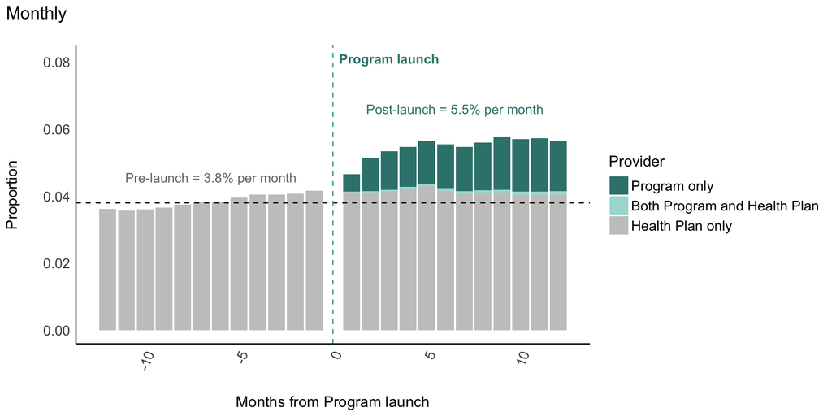

```r
# Monthly utilization
plot_monthly_avg <- df_care_use %>%
  filter(month_year >= baseline_start_date) %>%
  filter(month_year <= spring_end_date) %>%
  mutate(
    months_std = case_when(
      month_year < spring_start_date ~ interval(spring_start_date, month_year) %/% months(1),
      month_year >= spring_start_date ~ interval(spring_start_date, month_year) %/% months(1) + 1
    ),
    phase = ifelse(month_year < spring_start_date, "Pre-launch", "Post-launch"),
    provider = "Spring"
    ) %>%
  # We need weights per employer per month
  group_by(customer_name, months_std) %>%
  mutate(employer_n = sum(!is.na(mh_appt_group))) %>%
  mutate(employer_weight = 1 / employer_n) %>% # employer weight by month
  group_by(mh_appt_group, months_std) %>%
  summarize(group_weight = sum(employer_weight)) %>%
  group_by(months_std) %>%
  mutate(mh_appt_in_month_proportion = group_weight / sum(group_weight)) %>%
  mutate(
    mh_appt_group = case_when(
      mh_appt_group == "Carrier only" ~ "Health Plan only",
      mh_appt_group == "Both Spring and Carrier" ~ "Both Program and Health Plan",
      mh_appt_group == "Spring only" ~ "Program only",
      TRUE ~ mh_appt_group)
    ) %>%
  mutate(mh_appt_group = factor(mh_appt_group, levels = c("Program only", "Both Program and Health Plan", "Health Plan only"))) %>%
  filter(mh_appt_group != "No appointments") %>%
  arrange(mh_appt_group, months_std)


## Plot

## Make some plotting locations
pre_mean_avg <- round(
  sum(plot_monthly_avg$mh_appt_in_month_proportion[plot_monthly_avg$months_std < 0])/12,
  3)
post_mean_avg <- round(
  sum(plot_monthly_avg$mh_appt_in_month_proportion[plot_monthly_avg$months_std > 0])/12,
  3)
max_avg <-max(
  plot_monthly_avg %>%
    group_by(months_std) %>%
    summarize(apps_in_month = sum(mh_appt_in_month_proportion)) %>%
    pull(apps_in_month)
)

## Plot
color_scheme <- c("#37837c","#A9DbD6", '#c7c7c7') # set colors

p1 <- ggplot(plot_monthly_avg, aes(x = months_std, y=mh_appt_in_month_proportion, group = mh_appt_group, fill = mh_appt_group)) +
  geom_bar(position="stack", stat="identity") +
  scale_fill_manual(values = color_scheme, name = "Provider") +
  theme_modern() +
  geom_hline(yintercept = pre_mean_avg, linetype = "dashed") +
  geom_vline(xintercept = 0, color = "#48ADA3", linetype = "dashed") +
  theme(axis.text.x = element_text(angle = 70, vjust = 1, hjust=1)) +
  annotate(geom = "text", x = 3, y = max_avg*1.4, label = "Program launch", color = "#37837c", fontface = "bold", size = 4) +
  annotate(geom = "text", x = -6.5, y = pre_mean_avg*1.2, label = paste0("Pre-launch = ", 100*pre_mean_avg, "% per month"), color = "#767676", size = 4) +
  annotate(geom = "text", x = 6.5, y = post_mean_avg*1.2, label = paste0("Post-launch = ", 100*post_mean_avg, "% per month"), color = "#37837c", size = 4) +
  labs(
    title = "Monthly",
    x = "Months from Program launch",
    y = "Proportion"
  )
p1
```

## 2.2 Annual utilization

```r
# Summarize to month level
df_phase_summary <- df_care_use %>%
  filter(month_year >= baseline_start_date) %>%
  filter(month_year <= spring_end_date) %>%
  mutate(phase = ifelse(month_year < spring_start_date, "Pre-launch", "Post-launch")) %>%
  mutate(phase = factor(phase, levels = c("Pre-launch", "Post-launch"))) %>%
  group_by(customer_name, carrier_member_id, phase) %>%
  summarize(
    carrier_tx_count_month = sum(carrier_tx_count_month),
    spring_tx_count_month = sum(spring_tx_count_month),
    carrier_therapist_count_month = sum(carrier_therapist_count_month),
    spring_therapist_count_month = sum(spring_therapist_count_month)
  ) %>%
  ungroup() %>%
  mutate(
    mh_appt_group = factor(case_when(
      carrier_tx_count_month > 0 & spring_tx_count_month > 0 ~ "Both Program and Health Plan",
      carrier_tx_count_month > 0 & spring_tx_count_month == 0 ~ "Health Plan only",
      carrier_tx_count_month == 0 & spring_tx_count_month > 0 ~ "Program only",
      carrier_tx_count_month == 0 & spring_tx_count_month == 0 ~ "No appointments"
    ),
    levels = c("Program only", "Both Program and Health Plan", "Health Plan only", "No appointments")
    ))

## Add weights
df_phase_summary <- df_phase_summary %>%
  mutate(any_utilization = ifelse(mh_appt_group == "No appointments", "no", "yes")) %>%
  mutate(any_utilization = as.factor(any_utilization)) %>%
  # make weights
  group_by(customer_name, phase) %>%
  mutate(employer_n = sum(!is.na(any_utilization))) %>%
  mutate(employer_weight = 1 / employer_n) %>%
  mutate(customer_name = as.factor(customer_name)) %>%
  ungroup()
```

## 2.3 Customer-average

```r
## Model

## Make survey design object with members nested in customers
d1 <- svydesign(
  id = ~ customer_name + carrier_member_id, # members nested in customers. Order matters in this equation.
  weights = ~employer_weight,
  data = df_phase_summary)

## Model
m1 <- svyglm(any_utilization ~ phase, family = binomial, design = d1)

## Point estimates
month_estimates <- predictions(m1, newdata = df_phase_summary %>% distinct(phase), type = "response") %>%
  arrange(phase) %>%
  data.frame() %>%
  mutate(
    mh_appt_group = "Program only",
    percent = 100 * estimate,
    percent.low = 100 * conf.low,
    percent.high = 100 * conf.high
    )
month_estimates
```

```
##   rowid   estimate  std.error statistic      p.value   conf.low conf.high
## 1     1 0.08307503 0.01412669  5.880713 4.085021e-09 0.05538722 0.1107628
## 2     2 0.12236422 0.01719619  7.115777 1.112843e-12 0.08866031 0.1560681
##         phase any_utilization mh_appt_group   percent percent.low percent.high
## 1  Pre-launch              no  Program only  8.307503    5.538722     11.07628
## 2 Post-launch              no  Program only 12.236422    8.866031     15.60681
```

```r
## Test pre-post difference
hypotheses(m1, hypothesis = "exp(b1 + b2) / (1 + exp(b1 + b2)) - exp(b1) / (1 + exp(b1)) = 0")
```

```
##
##                                                             Term Estimate
##  exp(b1 + b2) / (1 + exp(b1 + b2)) - exp(b1) / (1 + exp(b1)) = 0   0.0393
##  Std. Error    z Pr(>|z|)  2.5 % 97.5 %
##     0.00584 6.73   <0.001 0.0278 0.0507
##
## Columns: term, estimate, std.error, statistic, p.value, conf.low, conf.high
```

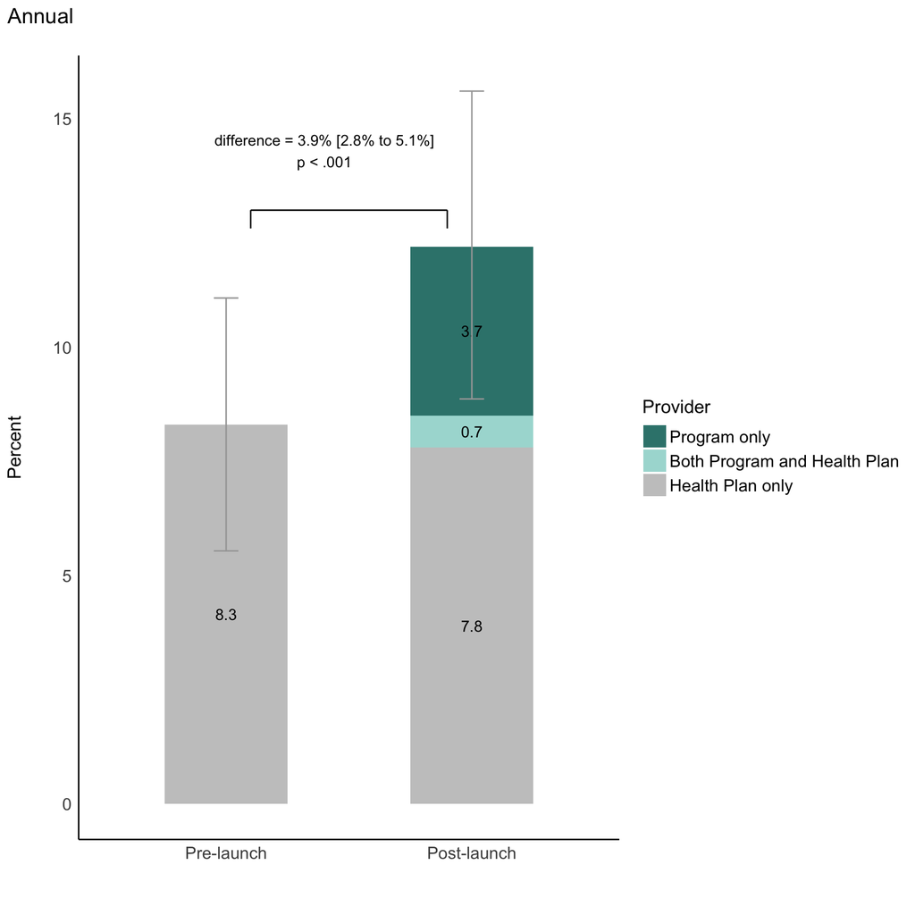

```r
# Plot weighted data
care_use_avg <- df_phase_summary %>%
  group_by(customer_name, phase) %>%
  mutate(employer_n = sum(!is.na(mh_appt_group))) %>%
  mutate(employer_weight = 1 / employer_n) %>% # employer weight by month
  group_by(phase, mh_appt_group) %>%
  summarize(group_weight = sum(employer_weight)) %>%
  group_by(phase) %>%
  mutate(proportion = group_weight / sum(group_weight)) %>%
  filter(mh_appt_group != "No appointments") %>%
  arrange(mh_appt_group, phase) %>%
  mutate(percent = 100 * round(proportion, 3))


## plot
color_scheme <- c("#37837c","#A9DbD6", '#c7c7c7') # set colors

p2 <- ggplot(care_use_avg, aes(x = phase, y=percent, group = mh_appt_group, fill = mh_appt_group)) +
  geom_bar(position="stack", stat="identity", width = 0.5) +
  scale_fill_manual(values = color_scheme, name = "Provider") +
  geom_text(aes(label=percent), position = position_stack(vjust = 0.5), colour = "black") +
  geom_errorbar(data = month_estimates, aes(ymin = percent.low, ymax = percent.high, width = 0.1), color = "grey65", show.legend = F) +
  annotate(geom = "segment", x = 1.1, xend = 1.1, y = 12.6, yend = 13) +
  annotate(geom = "segment", x = 1.9, xend = 1.9, y = 12.6, yend = 13) +
  annotate(geom = "segment", x = 1.1, xend = 1.9, y = 13, yend = 13) +
  annotate(geom = "text", x = 1.4, y = 14.3, label = "difference = 3.9% [2.8% to 5.1%]\np < .001", hjust = 0.5, size=3.75) +
  theme_modern() +
  labs(
    title = "Annual",
    x = "",
    y = "Percent",
    group = "",
    fill = ""
  )
p2
```

## 2.4 Figure 1: Utilization

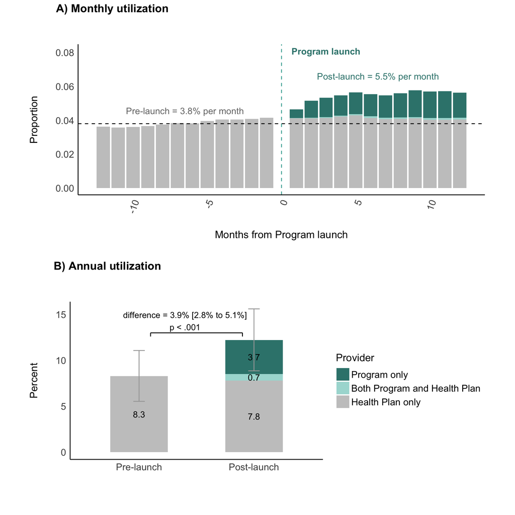

```r
plot_grid(
  p1 + theme(legend.position = "none") + labs(title = ""),
  p2 + labs(title = ""),
  nrow=2,
  labels = c("A) Monthly utilization", "B) Annual utilization"),
  scale = .9
)
```

# 3 Cohort comparisons

To determine Spring’s impact on Wellstar, Pepsi, Hearst, Docusign, Tegna, Western Governors University, IDEXX’s total cost of care, we conducted a matching study. We identified the group of people who engaged with a Spring provider, a risk-matched group that did not use Spring, and compared the spend of both groups. Research demonstrates that spend increases at the time of a mental health diagnosis, so we compared changes in each group’s spending from the year prior to receiving a MH diagnosis to the year after receiving a diagnosis, using a difference-in-differences design.

## 3.1 Data funnel

This table shows each step where participants were funneled into the analytic sample.

```r
match_funnel <- df_matched_orig %>%
  group_by(spring_dummy) %>%
  summarize(
    n = n_distinct(customer_name, carrier_member_id),
    filter_name = "Maintained in matching study"
    ) %>%
  mutate(total_n = sum(n)) %>%
  pivot_wider(
    id_cols = c(filter_name, total_n),
    names_from = spring_dummy,
    values_from = n
  )

# Fix different filter names
data_funnel <- data_funnel %>%
  mutate(filter_name = str_replace(filter_name, "No previous mental health diagnosis within", "No previous mental health treatment within"))

# Print
data_funnel %>%
  group_by(filter_name) %>%
  summarize(across(-customer_name, sum)) %>%
  rbind(match_funnel) %>%
  arrange(-total_n) %>%
  kbl(caption = "Participant funnel through inclusion criteria") %>%
  kable_classic(full_width = T, html_font = "Cambria")
```

Participant funnel through inclusion criteria

| filter_name | total_n | Health Plan | Spring |
| --- | --- | --- | --- |
| Insured by Health Plan any time in study year | 373879 | 366661 | 7218 |
| Mental health diagnosis after Spring launch | 67295 | 60089 | 7206 |
| No previous mental health treatment within 6 months of study year diagnosis | 42537 | 36887 | 5650 |
| Aged 5 and older | 41303 | 35654 | 5649 |
| Member must have 6 months pre and 1 months post | 40899 | 35273 | 5626 |
| Filter out patients with transplants or end-stage renal disease | 40829 | 35209 | 5620 |
| Did not receive treatment from both Spring and Health Plan | 40158 | 35209 | 4949 |
| Maintained in matching study | 13990 | 9083 | 4907 |

## 3.2 Summarize unmatched data

```r
df_unmatched_table <- df_analyze_all %>%
  filter(index_date >= spring_start_date) %>%
  group_by(carrier_member_id, spring_dummy, age_at_index, member_sex, cc_any, cc_asthma_copd, cc_diabetes, cc_hypertension, cc_heart, cc_stroke, cc_kidney, cc_osteo, cc_cancer) %>%
  arrange(month_year) %>%
  summarize(
    carrier_mh_dx = first(carrier_primary_mh_dx, na_rm = TRUE),
    spring_mh_dx = first(spring_primary_mh_dx, na_rm = TRUE),
    risk_score_dx = risk_score[months == 1]
  ) %>%
  ungroup() %>%
  mutate(mh_dx = coalesce(spring_mh_dx, carrier_mh_dx)) %>%
  mutate(dx_collapsed = fct_collapse(mh_dx,
                                   mood = "mood",
                                   anxiety = "anxiety",
                                   sud = "sud",
                                   other = c("personality", "psychotic", "intellectual disability", "physical behavioral", "physiological", "developmental", "child onset", "unspecified")
  )) %>%
  select(-c(carrier_mh_dx, spring_mh_dx)) %>%
  ungroup()

## Examine overall table
### NOTE: p-value function is broken so currently dropping
table1( ~ age_at_index + member_sex + mh_dx + dx_collapsed + risk_score_dx + cc_any + cc_asthma_copd + cc_diabetes + cc_hypertension + cc_heart
        + cc_stroke + cc_kidney + cc_osteo + cc_cancer | spring_dummy,
        overall = F,
        render.missing = NULL,
       render.categorical = "FREQ (PCTnoNA%)",
        data=df_unmatched_table)
```

|  | Health Plan (N=35209) | Spring (N=4950) |
| --- | --- | --- |
| age_at_index |  |  |
| Mean (SD) | 34.9 (16.1) | 37.3 (11.8) |
| Median [Min, Max] | 35.0 [5.00, 96.0] | 36.0 [6.00, 74.0] |
| member_sex |  |  |
| female | 19404 (55.1%) | 3308 (66.8%) |
| male | 15799 (44.9%) | 1641 (33.2%) |
| mh_dx |  |  |
| mood | 6864 (19.7%) | 826 (20.8%) |
| anxiety | 16550 (47.4%) | 2927 (73.6%) |
| sud | 4572 (13.1%) | 110 (2.77%) |
| personality | 166 (0.476%) | 13 (0.327%) |
| psychotic | 93 (0.267%) | 0 (0%) |
| physical behavioral | 1381 (3.96%) | 16 (0.402%) |
| physiological | 250 (0.717%) | 5 (0.126%) |
| intellectual disability | 22 (0.0631%) | 0 (0%) |
| developmental | 801 (2.30%) | 9 (0.226%) |
| child onset | 4160 (11.9%) | 71 (1.78%) |
| unspecified | 26 (0.0745%) | 1 (0.0251%) |
| dx_collapsed |  |  |
| mood | 6864 (19.7%) | 826 (20.8%) |
| anxiety | 16550 (47.4%) | 2927 (73.6%) |
| sud | 4572 (13.1%) | 110 (2.77%) |
| other | 6899 (19.8%) | 115 (2.89%) |
| risk_score_dx |  |  |
| Mean (SD) | 1.84 (4.83) | 1.36 (3.41) |
| Median [Min, Max] | 0.494 [0.102, 120] | 0.458 [0.102, 50.4] |
| cc_any |  |  |
| no | 23109 (65.6%) | 3566 (72.0%) |
| yes | 12100 (34.4%) | 1384 (28.0%) |
| cc_asthma_copd |  |  |
| no | 31706 (90.1%) | 4509 (91.1%) |
| yes | 3503 (9.95%) | 441 (8.91%) |
| cc_diabetes |  |  |
| no | 32768 (93.1%) | 4651 (94.0%) |
| yes | 2441 (6.93%) | 299 (6.04%) |
| cc_hypertension |  |  |
| no | 27287 (77.5%) | 4127 (83.4%) |
| yes | 7922 (22.5%) | 823 (16.6%) |
| cc_heart |  |  |
| no | 34090 (96.8%) | 4864 (98.3%) |
| yes | 1119 (3.18%) | 86 (1.74%) |
| cc_stroke |  |  |
| no | 34981 (99.4%) | 4933 (99.7%) |
| yes | 228 (0.648%) | 17 (0.343%) |
| cc_kidney |  |  |
| no | 34775 (98.8%) | 4913 (99.3%) |
| yes | 434 (1.23%) | 37 (0.747%) |
| cc_osteo |  |  |
| no | 34908 (99.1%) | 4909 (99.2%) |
| yes | 301 (0.855%) | 41 (0.828%) |
| cc_cancer |  |  |
| no | 33904 (96.3%) | 4818 (97.3%) |
| yes | 1305 (3.71%) | 132 (2.67%) |

## 3.3 Table 1: Participant characteristics for matched groups

```r
df_match_table <- df_matched_orig %>%
  group_by(carrier_member_id) %>%
  arrange(months) %>%
  mutate(
    therapy_sessions_cum = case_when(
      spring_dummy == "Spring" ~ cumsum(spring_therapist_count_month),
      spring_dummy == "Health Plan" ~ cumsum(carrier_therapist_count_month)
    ),
    therapy_sessions_total = sum(spring_therapist_count_month, carrier_therapist_count_month, na.rm=T),
    session_count_total = sum(spring_tx_count_month, carrier_tx_count_month, na.rm=T),
    months_diagnosed = interval(index_date, spring_end_date) %/% months(1) + 1,
    cc_any2 = case_when(
      cc_cancer == "yes" ~ "yes",
      cc_hypertension == "yes" ~ "yes",
      cc_diabetes == "yes" ~ "yes",
      excl_pregnancy == "yes" ~ "yes",
      cc_asthma_copd == "yes" ~ "yes",
      TRUE ~ "no"
    )
  ) %>%
  mutate(
    any_bh = ifelse(session_count_total > 0, "yes", "no"),
    bh_if_engaged = ifelse(session_count_total > 0, session_count_total, NA),
    therapy_if_engaged = ifelse(therapy_sessions_total > 0, therapy_sessions_total, NA)
    ) %>%
  group_by(carrier_member_id, cc_any2, cc_asthma_copd, cc_diabetes, cc_hypertension, cc_cancer, excl_pregnancy) %>%
  arrange(months) %>%
  slice_head() %>%
  ungroup() %>%
  mutate(spring_dummy = factor(spring_dummy, labels = c("Control", "Spring Health")))


# Weighted Table 1
library(survey)
library(tableone)
t1_design <- svydesign(ids = ~carrier_member_id, strata = ~spring_dummy, weights = ~weights_nn,
                       nest = TRUE, data = df_match_table)

t1 <- svyCreateTableOne(
  vars = c("age_at_index", "member_sex", "dx_imputed", "risk_score_dx", "months_diagnosed",
           "cc_asthma_copd", "cc_diabetes", "cc_hypertension", "cc_cancer", "excl_pregnancy",  "any_bh", "bh_if_engaged"),
  strata = "spring_dummy",
  data = t1_design)

# Make adjusted p-values
print(t1, pDigits=10, catDigits=1, contDigits=2) %>%
  data.frame() %>%
  rownames_to_column(var = "Characteristic") %>%

  # Format for kbl table
  mutate(
    p = ifelse(p == "<0.0000000001", .0000000001, p),
    adj_p = p.adjust(p, method = "BH"),
    adj_p = ifelse(adj_p >= .06, round(adj_p, 2), round(adj_p, 3)),
    adj_p = ifelse(adj_p < .001, "< 0.001", adj_p),
    adj_p = ifelse(adj_p > .999, " > 0.999", adj_p)
  ) %>%
  rename(Program = Spring.Health) %>%
  mutate(across(everything(), ~ifelse(is.na(.), "", .))) %>%
  kableone() %>%
  kable_classic(full_width = FALSE, html_font = "Cambria") %>%
  remove_column(c(4, 5))
```

| Characteristic | Control | Program | adj_p |
| --- | --- | --- | --- |
| n | 9083.00 | 4907.00 |  |
| age_at_index (mean (SD)) | 37.32 (13.92) | 37.36 (11.75) | > 0.999 |
| member_sex = male (%) | 3196.6 (35.2) | 1626.0 ( 33.1) | 0.038 |
| dx_imputed (%) |  |  | > 0.999 |
| mood | 1907.2 (21.0) | 1031.0 ( 21.0) |  |
| anxiety | 6661.5 (73.3) | 3598.0 ( 73.3) |  |
| sud | 257.1 ( 2.8) | 139.0 ( 2.8) |  |
| other | 257.1 ( 2.8) | 139.0 ( 2.8) |  |
| risk_score_dx (mean (SD)) | 1.32 (3.25) | 1.32 (3.25) | > 0.999 |
| months_diagnosed (mean (SD)) | 6.68 (3.42) | 6.52 (3.47) | 0.023 |
| cc_asthma_copd = yes (%) | 759.4 ( 8.4) | 439.0 ( 8.9) | 0.37 |
| cc_diabetes = yes (%) | 557.7 ( 6.1) | 293.0 ( 6.0) | 0.92 |
| cc_hypertension = yes (%) | 1937.8 (21.3) | 814.0 ( 16.6) | < 0.001 |
| cc_cancer = yes (%) | 296.0 ( 3.3) | 130.0 ( 2.6) | 0.09 |
| excl_pregnancy = yes (%) | 412.5 ( 4.5) | 253.0 ( 5.2) | 0.18 |
| any_bh = yes (%) | 3070.8 (33.8) | 4907.0 (100.0) | < 0.001 |
| bh_if_engaged (mean (SD)) | 7.46 (8.46) | 4.68 (4.76) | < 0.001 |

# 4 Medical spending outcomes

## 4.1 Models

Below are the results of the total cost of care study across the entire population and the matched group only.

```r
# Add net
df_matched <- df_matched_orig %>%

  # Convert paid to allowed
  mutate(across(c(med_pmpm,
                  med_pmpm_trunc,
                  med_pmpm_trunc_therapy_mh,
                  med_pmpm_trunc_ov_mh,
                  med_pmpm_trunc_er_mh,
                  med_pmpm_trunc_ip_mh,
                  med_pmpm_trunc_hosp_op_mh,
                  med_pmpm_trunc_other_mh,
                  med_pmpm_trunc_therapy_nonmh,
                  med_pmpm_trunc_ov_nonmh,
                  med_pmpm_trunc_er_nonmh,
                  med_pmpm_trunc_ip_nonmh,
                  med_pmpm_trunc_hosp_op_nonmh,
                  med_pmpm_trunc_other_nonmh),
                ~ifelse(customer_name == "Hearst" | customer_name == "Western Governors University", .x/.8, .x)
  )) %>%
  #Add net
  mutate(
    med_pmpm_net = med_pmpm + effective_session_fee * spring_tx_count_month,
    med_pmpm_trunc_net = med_pmpm_trunc + effective_session_fee * spring_tx_count_month,
    med_pmpm_therapy_mh_net = med_pmpm_therapy_mh + effective_session_fee * spring_tx_count_month,
    med_pmpm_trunc_therapy_mh_net = med_pmpm_trunc_therapy_mh + effective_session_fee * spring_tx_count_month
  )

# Aggregate to mental and physical health spend
df_matched <- df_matched %>%
  mutate(
    med_pmpm_trunc_mh_net =
      med_pmpm_trunc_therapy_mh_net +
      med_pmpm_trunc_ov_mh +
      med_pmpm_trunc_er_mh +
      med_pmpm_trunc_ip_mh +
      med_pmpm_trunc_hosp_op_mh +
      med_pmpm_trunc_other_mh,
    med_pmpm_trunc_nonmh =
      med_pmpm_trunc_therapy_nonmh +
      med_pmpm_trunc_ov_nonmh +
      med_pmpm_trunc_er_nonmh +
      med_pmpm_trunc_ip_nonmh +
      med_pmpm_trunc_hosp_op_nonmh +
      med_pmpm_trunc_other_nonmh
  )

## Let's recode customer so the intercept reflects the average across participants
#cust_recode <- df_matched %>%
#  group_by(customer_name) %>%
#  summarize(cust_row_count = n()) %>%
#  ungroup() %>%
#  mutate(cust_prop = cust_row_count/sum(cust_row_count)) %>%
#  select(customer_name, cust_prop) %>%
#  pivot_wider(names_from = customer_name, values_from = cust_prop)


## Model
m1_gross_unmatched <- lmer(med_pmpm_trunc ~ 1 + spring_dummy + spring_dummy*phase +
             (1 | carrier_member_id),
           #weights = weights_nn,
           data = df_analyze_all)

m1_gross <- lmer(med_pmpm_trunc ~ 1 + spring_dummy + spring_dummy*phase +
             (1 | carrier_member_id) +
             (1 | subclass_nn),
           weights = weights_nn,
           data = df_matched)

m1_net <- lmer(med_pmpm_trunc_net ~ 1 + spring_dummy + spring_dummy*phase +
             (1 | carrier_member_id) +
             (1 | subclass_nn),
           weights = weights_nn,
           data = df_matched)

tab_model(m1_net,
          pred.labels = c("Baseline PMPM", "Baseline difference (Spring - Control)", "Control pre-post change", "Diff-in-diff (Spring change - Control change)"),
          title = "Net medical spending")
```

Net medical spending

|  | med pmpm trunc net |  |  |
| --- | --- | --- | --- |
| Predictors | Estimates | CI | p |
| Baseline PMPM | 464.60 | 431.96 – 497.24 | **<0.001** |
| Baseline difference (Spring - Control) | 8.30 | -35.72 – 52.32 | 0.712 |
| Control pre-post change | 333.45 | 302.49 – 364.42 | **<0.001** |
| Diff-in-diff (Spring change - Control change) | -157.77 | -210.13 – -105.41 | **<0.001** |
| Random Effects |  |  |  |
| σ<sup>2</sup> | 9386772.03 |  |  |
| τ<sub>00</sub> <sub>carrier_member_id</sub> | 779483.23 |  |  |
| τ<sub>00</sub> <sub>subclass_nn</sub> | 486659.86 |  |  |
| ICC | 0.12 |  |  |
| N <sub>carrier_member_id</sub> | 13990 |  |  |
| N <sub>subclass_nn</sub> | 4910 |  |  |
| Observations | 257326 |  |  |
| Marginal R<sup>2</sup> / Conditional R<sup>2</sup> | 0.002 / 0.121 |  |  |

```r
# Sensitivity
tab_model(m1_gross_unmatched, m1_gross, m1_net,
          show.ci=F,
          show.se=T,
          pred.labels = c("Baseline PMPM", "Baseline difference (Spring - Control)", "Control pre-post change", "Diff-in-diff (Spring change - Control change)"),
          dv.labels = c("No matching - Gross spending", "Matched group spending - Gross", "Total Spend - Net",
          title = "Sensitivity analysis - Medical spending"))
```

|  | No matching - Gross spending |  |  | Matched group spending - Gross |  |  | Total Spend - Net |  |  | Sensitivity analysis - Medical spending |
| --- | --- | --- | --- | --- | --- | --- | --- | --- | --- | --- |
| Predictors | Estimates | std. Error | p | Estimates | std. Error | p | Estimates | std. Error | p |  |
| Baseline PMPM | 531.84 | 9.99 | **<0.001** | 464.59 | 16.65 | **<0.001** | 464.60 | 16.65 | **<0.001** |  |
| Baseline difference (Spring - Control) | -73.90 | 28.51 | **0.010** | 8.35 | 22.45 | 0.710 | 8.30 | 22.46 | 0.712 |  |
| Control pre-post change | 370.56 | 8.91 | **<0.001** | 333.16 | 15.79 | **<0.001** | 333.45 | 15.80 | **<0.001** |  |
| Diff-in-diff (Spring change - Control change) | -382.23 | 26.25 | **<0.001** | -340.86 | 26.70 | **<0.001** | -157.77 | 26.72 | **<0.001** |  |
| Random Effects |  |  |  |  |  |  |  |  |  |  |
| σ<sup>2</sup> | 12203144.92 |  |  | 9375909.06 |  |  | 9386772.03 |  |  |  |
| τ<sub>00</sub> | 2456178.81 <sub>carrier_member_id</sub> |  |  | 779622.55 <sub>carrier_member_id</sub> |  |  | 779483.23 <sub>carrier_member_id</sub> |  |  |  |
|  |  |  |  | 486719.27 <sub>subclass_nn</sub> |  |  | 486659.86 <sub>subclass_nn</sub> |  |  |  |
| ICC | 0.17 |  |  | 0.12 |  |  | 0.12 |  |  |  |
| N | 40158 <sub>carrier_member_id</sub> |  |  | 13990 <sub>carrier_member_id</sub> |  |  | 13990 <sub>carrier_member_id</sub> |  |  |  |
|  |  |  |  | 4910 <sub>subclass_nn</sub> |  |  | 4910 <sub>subclass_nn</sub> |  |  |  |
| Observations | 764624 |  |  | 257326 |  |  | 257326 |  |  |  |
| Marginal R<sup>2</sup> / Conditional R<sup>2</sup> | 0.002 / 0.169 |  |  | 0.002 / 0.121 |  |  | 0.002 / 0.121 |  |  |  |

## 4.2 Table 2: Medical spending outcomes with bootstrap standard errors

```r
set.seed(8102018)
nboot <- 5000
ncores <- 5

cl <- makeCluster(ncores, type = "PSOCK") # make a socket cluster
doParallel::registerDoParallel(cl)          # how the CPU knows to run in parallel

# Run bootstrap
m1_boot <- foreach(B = rep(nboot/ncores, ncores),
                       .combine = combine_lmeresamp,
                       .packages = c("lmeresampler", "lme4")) %dopar% {
                         bootstrap(m1_net, .f = fixef, type = "residual", B = B)
                       }
stopCluster(cl)

# Get CIs
confint(m1_boot, type = "perc") %>%
  select(term, estimate, lower, upper) %>%
  mutate(across(estimate:upper, ~round(.x, 2))) %>%
  kableone() %>%
  kable_classic(full_width = FALSE, html_font = "Cambria")
```

| term | estimate | lower | upper |
| --- | --- | --- | --- |
| (Intercept) | 464.60 | 443.39 | 486.98 |
| spring_dummySpring | 8.30 | -36.03 | 52.76 |
| phasepost_tx | 333.45 | 300.70 | 365.98 |
| spring_dummySpring:phasepost_tx | -157.77 | -210.46 | -106.44 |

## 4.3 Figure 2: Net medical spending

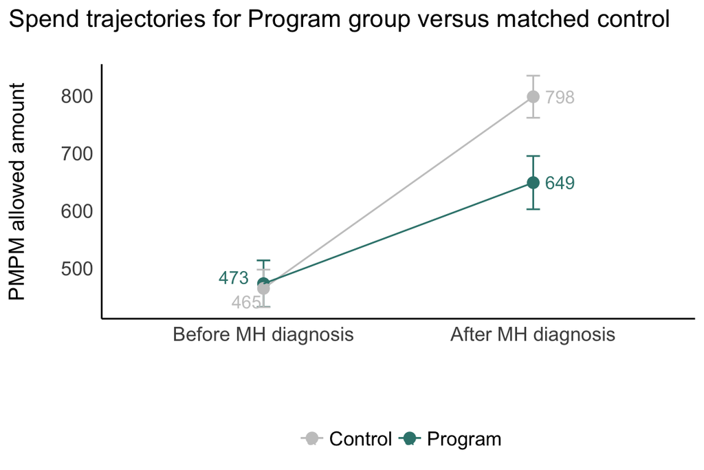

```r
df_plot <- df_matched %>%
  ungroup() %>%
  distinct(spring_dummy, phase) %>%
  mutate(
    phase_label = case_when(
      phase == "pre_tx" ~ "Before MH diagnosis",
      phase == "post_tx" ~ "After MH diagnosis"
    )
  ) %>%
  mutate(phase_label = factor(phase_label, levels = c("Before MH diagnosis", "After MH diagnosis")))

df_plot_total <- predictions(m1_net, newdata = df_plot, re.form = ~0)


# Overall with error bars
color_scheme <- c('#c7c7c7', "#37837c")

ggplot(df_plot_total, aes(x=phase_label, y=estimate, ymin=conf.low, ymax=conf.high, group = spring_dummy, color = spring_dummy)) +
  geom_errorbar(width = 0.05) +
  geom_point(size=3) +
  geom_line() +
  scale_color_manual(values = color_scheme, labels = c("Control", "Program")) +
  geom_text_repel(aes(label=round(estimate, 0)), hjust = ifelse(df_plot$phase_label == "Before MH diagnosis", 1.4, -0.4)) +
  theme_modern() +
  theme(legend.position = "bottom") +
  labs(
    title = "Spend trajectories for Program group versus matched control",
    x = "",
    y = "PMPM allowed amount",
    color = ""
  )
```

## 4.4 Pharmacy spend models

```r
# Only run rx models if client has rx data
## No matching
m1_rx_no_match <- lmer(rx_pmpm_trunc ~ 1 + spring_dummy + spring_dummy*phase + customer_name +
             (1 | carrier_member_id),
           data = filter(df_analyze_all, index_date >= spring_start_date))

## Matching
m1_rx_yes_match <- lmer(rx_pmpm_trunc ~ 1 + spring_dummy + spring_dummy*phase + customer_name +
             (1 | carrier_member_id) +
             (1 | subclass_nn),
           weights = weights_nn,
           data = df_matched)

tab_model(m1_rx_no_match, m1_rx_yes_match, show.ci=F, show.se=T,
          pred.labels = c("Baseline PMPM", "Baseline difference (Spring - Control)", "Control pre-post change", "Diff-in-diff (Spring change - Control change)"),
          dv.labels = c("Umatched", "Matched"),
          title = "Spring effect on gross pharmacy spending")
```

Spring effect on gross pharmacy spending

|  | Umatched |  |  | Matched |  |  |
| --- | --- | --- | --- | --- | --- | --- |
| Predictors | Estimates | std. Error | p | Estimates | std. Error | p |
| (Intercept) | 191.95 | 30.45 | **<0.001** | 133.41 | 34.62 | **<0.001** |
| spring_dummySpring | -27.03 | 15.54 | 0.082 | 4.83 | 14.21 | 0.734 |
| phasepost_tx | 43.58 | 2.49 | **<0.001** | 44.79 | 3.95 | **<0.001** |
| customer_nameHearst | -201.33 | 36.34 | **<0.001** | -150.27 | 43.16 | **<0.001** |
| customer_nameIDEXX | 4.58 | 36.32 | 0.900 | 27.66 | 42.03 | 0.510 |
| customer_namePepsi | -28.18 | 30.92 | 0.362 | 4.85 | 36.71 | 0.895 |
| customer_nameTegna | -199.39 | 38.65 | **<0.001** | -149.25 | 44.21 | **0.001** |
| customer_nameWellstar | 56.78 | 33.31 | 0.088 | 59.35 | 39.10 | 0.129 |
| customer_nameWestern Governors University | -1.50 | 36.16 | 0.967 | 10.81 | 40.52 | 0.790 |
| spring_dummySpring:phasepost_tx | -8.01 | 7.33 | 0.275 | -8.03 | 6.69 | 0.230 |
| Random Effects |  |  |  |  |  |  |
| σ<sup>2</sup> | 941456.73 |  |  | 576477.52 |  |  |
| τ<sub>00</sub> | 902654.73 <sub>carrier_member_id</sub> |  |  | 589173.20 <sub>carrier_member_id</sub> |  |  |
|  |  |  |  | 91699.79 <sub>subclass_nn</sub> |  |  |
| ICC | 0.49 |  |  | 0.54 |  |  |
| N | 40158 <sub>carrier_member_id</sub> |  |  | 13990 <sub>carrier_member_id</sub> |  |  |
|  |  |  |  | 4910 <sub>subclass_nn</sub> |  |  |
| Observations | 764663 |  |  | 257336 |  |  |
| Marginal R<sup>2</sup> / Conditional R<sup>2</sup> | 0.002 / 0.491 |  |  | 0.004 / 0.543 |  |  |

```r
# Sensitivity: heavy truncation
df_matched <- df_matched %>%
  mutate(
     rx_pmpm_trunc10k = ifelse(rx_pmpm_trunc > 10000, 10000, rx_pmpm_trunc),
     rx_pmpm_trunc5k = ifelse(rx_pmpm_trunc > 5000, 5000, rx_pmpm_trunc),
     rx_pmpm_trunc2.5k = ifelse(rx_pmpm_trunc > 2500, 2500, rx_pmpm_trunc)
    )

m1_rx_truncate10k <- lmer(rx_pmpm_trunc10k ~ 1 + spring_dummy + spring_dummy*phase + customer_name +
             (1 | carrier_member_id) +
             (1 | subclass_nn),
           weights = weights_nn,
           data = df_matched)

m1_rx_truncate5k <- lmer(rx_pmpm_trunc5k ~ 1 + spring_dummy + spring_dummy*phase + customer_name +
             (1 | carrier_member_id) +
             (1 | subclass_nn),
           weights = weights_nn,
           data = df_matched)

m1_rx_truncate2.5k <- lmer(rx_pmpm_trunc2.5k ~ 1 + spring_dummy + spring_dummy*phase + customer_name +
             (1 | carrier_member_id) +
             (1 | subclass_nn),
           weights = weights_nn,
           data = df_matched)

tab_model(m1_rx_yes_match,
          show.ci=T,
          show.se=T,
          pred.labels = c("Baseline PMPM", "Baseline difference (Spring - Control)", "Control pre-post change", "Diff-in-diff (Spring change - Control change)"),
          title = "Spring effect on net pharmacy spending")
```

Spring effect on net pharmacy spending

|  | rx pmpm trunc |  |  |  |
| --- | --- | --- | --- | --- |
| Predictors | Estimates | std. Error | CI | p |
| (Intercept) | 133.41 | 34.62 | -Inf – Inf | **<0.001** |
| spring_dummySpring | 4.83 | 14.21 | -Inf – Inf | 0.734 |
| phasepost_tx | 44.79 | 3.95 | -Inf – Inf | **<0.001** |
| customer_nameHearst | -150.27 | 43.16 | -Inf – Inf | **<0.001** |
| customer_nameIDEXX | 27.66 | 42.03 | -Inf – Inf | 0.510 |
| customer_namePepsi | 4.85 | 36.71 | -Inf – Inf | 0.895 |
| customer_nameTegna | -149.25 | 44.21 | -Inf – Inf | **0.001** |
| customer_nameWellstar | 59.35 | 39.10 | -Inf – Inf | 0.129 |
| customer_nameWestern Governors University | 10.81 | 40.52 | -Inf – Inf | 0.790 |
| spring_dummySpring:phasepost_tx | -8.03 | 6.69 | -Inf – Inf | 0.230 |
| Random Effects |  |  |  |  |
| σ<sup>2</sup> | 576477.52 |  |  |  |
| τ<sub>00</sub> <sub>carrier_member_id</sub> | 589173.20 |  |  |  |
| τ<sub>00</sub> <sub>subclass_nn</sub> | 91699.79 |  |  |  |
| ICC | 0.54 |  |  |  |
| N <sub>carrier_member_id</sub> | 13990 |  |  |  |
| N <sub>subclass_nn</sub> | 4910 |  |  |  |
| Observations | 257336 |  |  |  |
| Marginal R<sup>2</sup> / Conditional R<sup>2</sup> | 0.004 / 0.543 |  |  |  |

```r
tab_model(m1_rx_yes_match, m1_rx_truncate10k, m1_rx_truncate5k, m1_rx_truncate2.5k, show.ci=F, show.se=T,
          pred.labels = c("Baseline PMPM", "Baseline difference (Spring - Control)", "Control pre-post change", "Diff-in-diff (Spring change - Control change)"),
          dv.labels = c("Matched - Standard truncation", "Any baseline pharm spend", "Truncate 10k", "Truncate 5k", "Truncate 2.5k"),
          title = "Spring effect on gross pharmacy spending")
```

Spring effect on gross pharmacy spending

|  | Matched - Standard truncation |  |  | Any baseline pharm spend |  |  | Truncate 10k |  |  | Truncate 5k |  |  | Truncate 2.5k |
| --- | --- | --- | --- | --- | --- | --- | --- | --- | --- | --- | --- | --- | --- |
| Predictors | Estimates | std. Error | p | Estimates | std. Error | p | Estimates | std. Error | p | Estimates | std. Error | p |  |
| (Intercept) | 133.41 | 34.62 | **<0.001** | 103.73 | 22.84 | **<0.001** | 90.77 | 16.40 | **<0.001** | 76.96 | 11.08 | **<0.001** |  |
| spring_dummySpring | 4.83 | 14.21 | 0.734 | 5.99 | 8.39 | 0.475 | 2.66 | 5.88 | 0.651 | 1.65 | 3.94 | 0.676 |  |
| phasepost_tx | 44.79 | 3.95 | **<0.001** | 37.51 | 2.44 | **<0.001** | 32.13 | 1.74 | **<0.001** | 26.10 | 1.22 | **<0.001** |  |
| customer_nameHearst | -150.27 | 43.16 | **<0.001** | -118.19 | 28.60 | **<0.001** | -102.34 | 20.56 | **<0.001** | -86.36 | 13.89 | **<0.001** |  |
| customer_nameIDEXX | 27.66 | 42.03 | 0.510 | 29.98 | 27.80 | 0.281 | 25.48 | 19.98 | 0.202 | 18.64 | 13.50 | 0.167 |  |
| customer_namePepsi | 4.85 | 36.71 | 0.895 | 10.46 | 24.29 | 0.667 | 4.59 | 17.46 | 0.793 | 0.01 | 11.79 | 0.999 |  |
| customer_nameTegna | -149.25 | 44.21 | **0.001** | -117.42 | 29.26 | **<0.001** | -101.64 | 21.03 | **<0.001** | -85.76 | 14.21 | **<0.001** |  |
| customer_nameWellstar | 59.35 | 39.10 | 0.129 | 69.84 | 25.89 | **0.007** | 63.96 | 18.61 | **0.001** | 51.56 | 12.58 | **<0.001** |  |
| customer_nameWestern Governors University | 10.81 | 40.52 | 0.790 | 24.91 | 26.74 | 0.352 | 22.52 | 19.21 | 0.241 | 17.41 | 12.97 | 0.180 |  |
| spring_dummySpring:phasepost_tx | -8.03 | 6.69 | 0.230 | -9.34 | 4.14 | **0.024** | -7.75 | 2.94 | **0.008** | -4.91 | 2.07 | **0.018** |  |
| Random Effects |  |  |  |  |  |  |  |  |  |  |  |  |  |
| σ<sup>2</sup> | 576477.52 |  |  | 220737.06 |  |  | 111410.35 |  |  | 55141.68 |  |  |  |
| τ<sub>00</sub> | 589173.20 <sub>carrier_member_id</sub> |  |  | 203719.81 <sub>carrier_member_id</sub> |  |  | 99482.01 <sub>carrier_member_id</sub> |  |  | 44243.94 <sub>carrier_member_id</sub> |  |  |  |
|  | 91699.79 <sub>subclass_nn</sub> |  |  | 60584.05 <sub>subclass_nn</sub> |  |  | 33453.89 <sub>subclass_nn</sub> |  |  | 15604.40 <sub>subclass_nn</sub> |  |  |  |
| ICC | 0.54 |  |  | 0.54 |  |  | 0.54 |  |  | 0.52 |  |  |  |
| N | 13990 <sub>carrier_member_id</sub> |  |  | 13990 <sub>carrier_member_id</sub> |  |  | 13990 <sub>carrier_member_id</sub> |  |  | 13990 <sub>carrier_member_id</sub> |  |  |  |
|  | 4910 <sub>subclass_nn</sub> |  |  | 4910 <sub>subclass_nn</sub> |  |  | 4910 <sub>subclass_nn</sub> |  |  | 4910 <sub>subclass_nn</sub> |  |  |  |
| Observations | 257336 |  |  | 257336 |  |  | 257336 |  |  | 257336 |  |  |  |
| Marginal R<sup>2</sup> / Conditional R<sup>2</sup> | 0.004 / 0.543 |  |  | 0.008 / 0.549 |  |  | 0.012 / 0.550 |  |  | 0.017 / 0.529 |  |  |  |

# 5 Cost categories

## 5.1 Table 3: Cost categories

```r
# Mental health vs Physical health
m1_mh <- lmer(med_pmpm_trunc_mh_net ~ 1 + spring_dummy + spring_dummy*phase +
                (1 | carrier_member_id) +
                (1 | subclass_nn),
              weights = weights_nn,
              data = df_matched)

m1_nonmh <- lmer(med_pmpm_trunc_nonmh ~ 1 + spring_dummy + spring_dummy*phase +
                   (1 | carrier_member_id) +
                   (1 | subclass_nn),
                 weights = weights_nn,
                 data = df_matched)

# By category

cc1 <- lmer(med_pmpm_trunc_ov_mh ~ 1 + spring_dummy + spring_dummy*phase +
              (1 | carrier_member_id) +
              (1 | subclass_nn),
            weights = weights_nn,
            data = df_matched)

cc2 <- lmer(med_pmpm_trunc_er_mh ~ 1 + spring_dummy + spring_dummy*phase +
              (1 | carrier_member_id) +
              (1 | subclass_nn),
            weights = weights_nn,
            data = df_matched)

cc3 <- lmer(med_pmpm_trunc_hosp_op_mh ~ 1 + spring_dummy + spring_dummy*phase +
              (1 | carrier_member_id) +
              (1 | subclass_nn),
            weights = weights_nn,
            data = df_matched)

cc4 <- lmer(med_pmpm_trunc_ip_mh ~ 1 + spring_dummy + spring_dummy*phase +
              (1 | carrier_member_id) +
              (1 | subclass_nn),
            weights = weights_nn,
            data = df_matched)

cc5 <- lmer(med_pmpm_trunc_therapy_mh_net ~ 1 + spring_dummy + spring_dummy*phase +
              (1 | carrier_member_id) +
              (1 | subclass_nn),
            weights = weights_nn,
            data = df_matched)

cc6 <- lmer(med_pmpm_trunc_other_mh ~ 1 + spring_dummy + spring_dummy*phase +
              (1 | carrier_member_id) +
              (1 | subclass_nn),
            weights = weights_nn,
            data = df_matched)

## Non-MH
cc7 <- lmer(med_pmpm_trunc_ov_nonmh ~ 1 + spring_dummy + spring_dummy*phase +
              (1 | carrier_member_id) +
              (1 | subclass_nn),
            weights = weights_nn,
            data = df_matched)

cc8 <- lmer(med_pmpm_trunc_er_nonmh ~ 1 + spring_dummy + spring_dummy*phase +
              (1 | carrier_member_id) +
              (1 | subclass_nn),
            weights = weights_nn,
            data = df_matched)

cc9 <- lmer(med_pmpm_trunc_hosp_op_nonmh ~ 1 + spring_dummy + spring_dummy*phase +
              (1 | carrier_member_id) +
              (1 | subclass_nn),
            weights = weights_nn,
            data = df_matched)

cc10 <- lmer(med_pmpm_trunc_ip_nonmh ~ 1 + spring_dummy + spring_dummy*phase +
              (1 | carrier_member_id) +
              (1 | subclass_nn),
            weights = weights_nn,
            data = df_matched)

cc11 <- lmer(med_pmpm_trunc_therapy_nonmh ~ 1 + spring_dummy + spring_dummy*phase +
              (1 | carrier_member_id) +
              (1 | subclass_nn),
            weights = weights_nn,
            data = df_matched)

cc12 <- lmer(med_pmpm_trunc_other_nonmh ~ 1 + spring_dummy + spring_dummy*phase +
              (1 | carrier_member_id) +
              (1 | subclass_nn),
            weights = weights_nn,
            data = df_matched)

spend_cat <- rep(c("Office visits", "Emergency room", "Hospital outpatient", "Hospital inpatient", "Behavioral Health", "Other"), 2)
mh_spend <- c(rep("Mental health", 6), rep("Physical health", 6))
df_cc_list <- list()
df_table_list <- list()

# Make plot data
for (i in 1:12) {
  df_temp <- predictions(get(paste0("cc", i)), newdata = df_plot, re.form = ~0) %>%
    mutate(
      spend_category = spend_cat[i],
      mh = mh_spend[i]
      )
  df_cc_list[[i]] <- df_temp
}

# Make table data
for (i in 1:12) {
  df_temp <- hypotheses(get(paste0("cc", i)), "b4 = 0") %>%
    mutate(
      spend_category = spend_cat[i],
      mh = mh_spend[i]
      )
  df_table_list[[i]] <- df_temp
}

df_total_spend <- rbind(
    hypotheses(m1_mh, "b4 = 0"),
    hypotheses(m1_nonmh, "b4 = 0")
    ) %>%
  data.frame(
    spend_category = c("Total mental health", "Total physical health"),
    mh = c("Mental health", "Physical health")
    )


df_table_cost_cat <- df_table_list %>%
  bind_rows() %>%
  data.frame() %>%
  rbind(df_total_spend) %>%
  filter(!(spend_category == "Behavioral Health" & mh == "Physical health")) %>%
  select(mh, spend_category, estimate, conf.low, conf.high, p.value) %>%
  mutate(adj_p = p.adjust(p.value, method = "BH")) %>%
  mutate(adj_p = ifelse(adj_p < .001, "< 0.001", round(adj_p, 3))) %>%
  mutate(across(c(3:5), ~round(.x, 0))) %>%
  select(-p.value) %>%
  slice(1:6, 12, 7:11, 13) # get the rows in the correct order

df_table_cost_cat %>%
  kableone() %>%
  kable_classic(full_width = FALSE, html_font = "Cambria") %>%
  pack_rows(index = table(df_table_cost_cat$mh)) %>%
  remove_column(1)
```

| spend_category | estimate | conf.low | conf.high | adj_p |  |
| --- | --- | --- | --- | --- | --- |
| **Mental health** |  |  |  |  |  |
| Office visits | -20 | -21 | -19 | < 0.001 |  |
| Emergency room | -12 | -14 | -9 | < 0.001 |  |
| Hospital outpatient | -34 | -41 | -26 | < 0.001 |  |
| Hospital inpatient | -28 | -37 | -18 | < 0.001 |  |
| Behavioral Health | 149 | 147 | 151 | < 0.001 |  |
| Other | -25 | -32 | -18 | < 0.001 |  |
| Total mental health | 30 | 15 | 45 | < 0.001 |  |
| **Physical health** |  |  |  |  |  |
| Office visits | -8 | -16 | -1 | 0.021 |  |
| Emergency room | -12 | -19 | -4 | 0.003 |  |
| Hospital outpatient | -70 | -96 | -45 | < 0.001 |  |
| Hospital inpatient | -67 | -98 | -36 | < 0.001 |  |
| Other | -32 | -55 | -8 | 0.008 |  |
| Total physical health | -190 | -240 | -140 | < 0.001 |  |

## 5.2 Figure 3: Cost categories

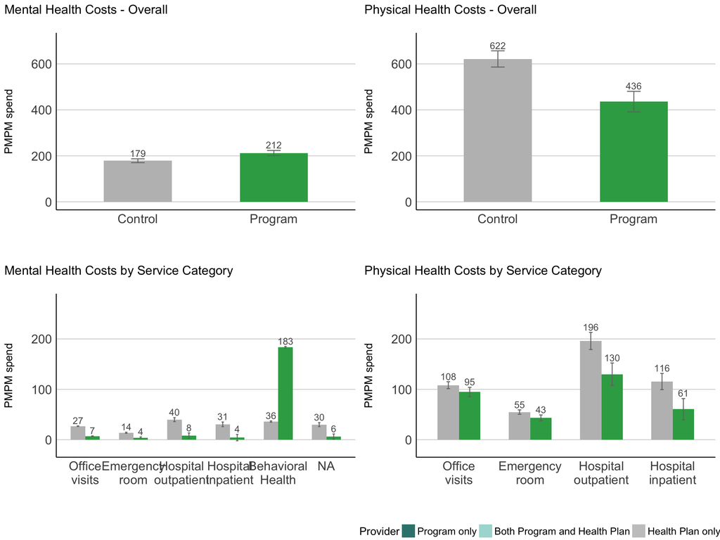

```r
df_cc_plot <- df_cc_list %>%
  bind_rows() %>%
  filter(phase == "post_tx") %>%
  select(spring_dummy, spend_category, mh, estimate, conf.low, conf.high) %>%
  mutate(spring_dummy = factor(spring_dummy, levels = c("Health Plan", "Spring"))) %>%
  mutate(spend_category = factor(spend_category, levels = c("Office visits", "Emergency room", "Hospital outpatient", "Hospital inpatient", "Behavioral Health")))


# Aesthetics
y_total <- 700 # total axis scale
y_cat <- 275 # category axis scale
cc_colors <- c("#34a853", "grey")

# Overall MH
df_plot_mh <- predictions(m1_mh, newdata = df_plot, re.form = ~0) %>%
  mutate(spend_category = "Mental Health - Overall") %>%
  filter(phase == "post_tx") %>%
  mutate(spring_dummy = ifelse(spring_dummy == "Spring", "Program", "Control"))

p3 <- ggplot(df_plot_mh, aes(x=spring_dummy, y=estimate, ymin = conf.low, ymax = conf.high, fill = spring_dummy, group = spring_dummy)) +
  geom_bar(stat = "identity", width = 0.5) +
  geom_errorbar(width = .1, color = "gray45") +
  scale_fill_manual(values = rev(cc_colors), labels = c("Control", "Program")) +
  geom_text(aes(x=spring_dummy, y=conf.high, label = round(estimate, 0), fill = NULL), colour = "gray35", size = 4, vjust=-0.3) +
  scale_y_continuous(breaks = seq(0, y_total, by = 200), limits = c(0, y_total)) +
  theme_modern() +
  theme(panel.grid.major.y = element_line(color = "gray85")) +
  theme(axis.text.x = element_text(size=15)) +
  theme(axis.text.y = element_text(size=15)) +
  theme(axis.title.x = element_text(size=18)) +
  theme(legend.text =  element_text(size=14)) +
  theme(
    legend.position = "none",
    legend.justification = "right",
    strip.text = element_text(size=15)
  ) +
  labs(
    title = "Mental Health Costs - Overall",
    x = "",
    y = "PMPM spend",
    fill = " "
  )
fig_legend <- get_legend(p1 + theme(legend.position = "bottom"))

# Overall PH
df_plot_nonmh <- predictions(m1_nonmh, newdata = df_plot, re.form = ~0) %>%
  filter(phase == "post_tx") %>%
  mutate(spend_category = "Physical Health - Overall") %>%
  mutate(spring_dummy = ifelse(spring_dummy == "Spring", "Program", "Control"))

p4 <- ggplot(df_plot_nonmh, aes(x=spring_dummy, y=estimate, ymin = conf.low, ymax = conf.high, fill = spring_dummy, group = spring_dummy)) +
  geom_bar(stat = "identity", width = 0.5) +
  geom_errorbar(width = .1, color = "gray45") +
  scale_fill_manual(values = rev(cc_colors), labels = c("Control", "Program")) +
  geom_text(aes(x=spring_dummy, y=conf.high, label = round(estimate, 0), fill = NULL), colour = "gray35", size = 4, vjust=-0.3) +
  scale_y_continuous(breaks = seq(0, y_total, by = 200), limits = c(0, y_total)) +
  theme_modern() +
  theme(panel.grid.major.y = element_line(color = "gray85")) +
  theme(axis.text.x = element_text(size=15)) +
  theme(axis.text.y = element_text(size=15)) +
  theme(axis.title.x = element_text(size=18)) +
  theme(legend.text =  element_text(size=14)) +
  theme(
    legend.position = "none",
    legend.justification = "right",
    strip.text = element_text(size=15)
  ) +
  labs(
    title = "Physical Health Costs - Overall",
    x = "",
    y = "PMPM spend",
    fill = " "
  )


# MH breakdown
p5 <- ggplot(filter(df_cc_plot, mh == "Mental health"), aes(x=spend_category, y=estimate, ymin = conf.low, ymax = conf.high, fill = spring_dummy, group = spring_dummy)) +
  geom_bar(stat = "identity", width = 0.6, position = position_dodge()) +
  geom_errorbar(position = position_dodge(0.6), width = .1, color = "gray45") +
  scale_fill_manual(values = rev(cc_colors), labels = c("Control", "Program")) +
  geom_text(aes(x=spend_category, y=conf.high, label = round(estimate, 0), fill = NULL), colour = "gray35", size = 4, vjust=-0.3, position = position_dodge(width = 0.6)) +
  scale_x_discrete(labels = scales::label_wrap(10)) +
  scale_y_continuous(breaks = seq(0, y_cat, by = 100), limits = c(-20, 275)) +
  theme_modern() +
  theme(panel.grid.major.y = element_line(color = "gray85")) +
  theme(axis.text.x = element_text(size=15)) +
  theme(axis.text.y = element_text(size=15)) +
  theme(axis.title.x = element_text(size=18)) +
  theme(legend.text =  element_text(size=14)) +
  theme(
    legend.position = "none",
    legend.justification = "right",
    strip.text = element_text(size=15)
  ) +
  labs(
    title = "Mental Health Costs by Service Category",
    x = "",
    y = "PMPM spend",
    fill = " "
  )


# PH breakdown
p6 <- ggplot(filter(df_cc_plot, mh == "Physical health" & spend_category != "Behavioral Health"), aes(x=spend_category, y=estimate, ymin = conf.low, ymax = conf.high, fill = spring_dummy, group = spring_dummy)) +
  geom_bar(stat = "identity", width = 0.6, position = position_dodge()) +
  geom_errorbar(position = position_dodge(0.6), width = .1, color = "gray45") +
  scale_fill_manual(values = rev(cc_colors), labels = c("Control", "Program")) +
  geom_text(aes(x=spend_category, y=conf.high, label = round(estimate, 0), fill = NULL), colour = "gray35", size = 4, vjust=-0.3, position = position_dodge(width = 0.6)) +
  scale_x_discrete(labels = scales::label_wrap(10)) +
  scale_y_continuous(breaks = seq(0, y_cat, by = 100), limits = c(-20, 275)) +
  theme_modern() +
  theme(panel.grid.major.y = element_line(color = "gray85")) +
  theme(axis.text.x = element_text(size=15)) +
  theme(axis.text.y = element_text(size=15)) +
  theme(axis.title.x = element_text(size=18)) +
  theme(legend.text =  element_text(size=14)) +
  theme(
    legend.position = "none",
    legend.justification = "right",
    strip.text = element_text(size=15)
  ) +
  labs(
    title = "Physical Health Costs by Service Category",
    x = "",
    y = "PMPM spend",
    fill = " "
  )

cowplot::plot_grid(p3, p4, p5, p6, NA, fig_legend, nrow=3, rel_heights = c(1,1,.07))
```

# 6 High cost conditions

## 6.1 High cost conditions models

```r
df_matched <- df_matched %>%
  mutate(cc_any = case_when(
    cc_any == "yes" ~ "yes",
    excl_pregnancy == "yes" ~ "yes",
    TRUE ~ cc_any
  ))


## Model
hcc1 <- lmer(med_pmpm_trunc_net ~ 1 + spring_dummy + spring_dummy*phase +
             cc_any + cc_any*(spring_dummy + spring_dummy*phase) +
             customer_name +
             (1 | carrier_member_id) +
             (1 | subclass_nn),
           weights = weights_nn,
           data = filter(df_matched, cc_any == "no" | cc_diabetes == "yes"))

hcc2 <- lmer(med_pmpm_trunc_net ~ 1 + spring_dummy + spring_dummy*phase +
             cc_any + cc_any*(spring_dummy + spring_dummy*phase) +
             customer_name +
             (1 | carrier_member_id) +
             (1 | subclass_nn),
           weights = weights_nn,
           data = filter(df_matched, cc_any == "no" | cc_hypertension == "yes"))

hcc3 <- lmer(med_pmpm_trunc_net ~ 1 + spring_dummy + spring_dummy*phase +
             cc_any + cc_any*(spring_dummy + spring_dummy*phase) +
             customer_name +
             (1 | carrier_member_id) +
             (1 | subclass_nn),
           weights = weights_nn,
           data = filter(df_matched, cc_any == "no" | cc_asthma_copd == "yes"))

hcc4 <- lmer(med_pmpm_trunc_net ~ 1 + spring_dummy + spring_dummy*phase +
             cc_any + cc_any*(spring_dummy + spring_dummy*phase) +
             customer_name +
             (1 | carrier_member_id) +
             (1 | subclass_nn),
           weights = weights_nn,
           data = filter(df_matched, cc_any == "no" | excl_pregnancy == "yes"))

hcc5 <- lmer(med_pmpm_trunc_net ~ 1 + spring_dummy + spring_dummy*phase +
             cc_any + cc_any*(spring_dummy + spring_dummy*phase) +
             customer_name +
             (1 | carrier_member_id) +
             (1 | subclass_nn),
           weights = weights_nn,
           data = filter(df_matched, cc_any == "no" | cc_cancer == "yes"))

m_no_hcc <- lmer(med_pmpm_trunc_net ~ 1 + spring_dummy + spring_dummy*phase +
             cc_any + cc_any*(spring_dummy + spring_dummy*phase) +
             customer_name +
             (1 | carrier_member_id) +
             (1 | subclass_nn),
           weights = weights_nn,
           data = df_matched)

tab_model(hcc1, hcc2, hcc3, hcc4, hcc5, m_no_hcc,
          dv.labels = c("Diabetes", "Hypertension", "Asthma/COPD", "Pregnancy", "Cancer", "Any HCC"),
          show.ci=F,
          show.se=T)
```

|  | Diabetes |  |  | Hypertension |  |  | Asthma/COPD |  |  | Pregnancy |  |  | Cancer |  |  | Any HCC |  |  |
| --- | --- | --- | --- | --- | --- | --- | --- | --- | --- | --- | --- | --- | --- | --- | --- | --- | --- | --- |
| Predictors | Estimates | std. Error | p | Estimates | std. Error | p | Estimates | std. Error | p | Estimates | std. Error | p | Estimates | std. Error | p | Estimates | std. Error | p |
| (Intercept) | 248.61 | 61.68 | **<0.001** | 232.79 | 60.24 | **<0.001** | 228.74 | 45.83 | **<0.001** | 258.33 | 36.24 | **<0.001** | 279.57 | 62.67 | **<0.001** | 262.45 | 58.22 | **<0.001** |
| spring dummy [Spring] | 14.36 | 19.82 | 0.469 | 9.34 | 26.06 | 0.720 | 9.75 | 19.99 | 0.626 | 6.24 | 17.18 | 0.716 | 9.24 | 23.66 | 0.696 | 11.17 | 28.00 | 0.690 |
| phase [post_tx] | 246.78 | 15.11 | **<0.001** | 247.47 | 18.40 | **<0.001** | 246.79 | 15.48 | **<0.001** | 245.80 | 14.69 | **<0.001** | 247.34 | 16.84 | **<0.001** | 247.38 | 19.94 | **<0.001** |
| cc any [yes] | 589.53 | 50.29 | **<0.001** | 426.35 | 34.27 | **<0.001** | 471.57 | 39.57 | **<0.001** | 792.84 | 43.32 | **<0.001** | 1728.38 | 74.07 | **<0.001** | 465.80 | 30.51 | **<0.001** |
| customer name [Hearst] | 125.18 | 77.95 | 0.108 | 83.83 | 74.69 | 0.262 | 65.01 | 57.59 | 0.259 | 2.61 | 45.74 | 0.954 | 78.23 | 79.23 | 0.323 | 57.76 | 71.88 | 0.422 |
| customer name [IDEXX] | 36.22 | 75.58 | 0.632 | 65.45 | 72.66 | 0.368 | 39.83 | 55.63 | 0.474 | 82.02 | 44.12 | 0.063 | 24.32 | 76.80 | 0.751 | 19.68 | 69.75 | 0.778 |
| customer name [Pepsi] | 21.28 | 66.13 | 0.748 | 62.58 | 63.81 | 0.327 | 34.89 | 48.79 | 0.475 | 6.47 | 38.50 | 0.867 | -15.97 | 67.12 | 0.812 | 19.39 | 61.16 | 0.751 |
| customer name [Tegna] | -77.88 | 79.72 | 0.329 | -86.96 | 76.41 | 0.255 | -70.06 | 58.99 | 0.235 | -76.80 | 46.74 | 0.100 | -146.20 | 80.95 | 0.071 | -129.64 | 73.55 | 0.078 |
| customer name [Wellstar] | 126.55 | 71.35 | 0.076 | 154.43 | 68.24 | **0.024** | 176.11 | 52.87 | **0.001** | 103.82 | 41.87 | **0.013** | 93.41 | 72.95 | 0.200 | 112.80 | 65.23 | 0.084 |
| customer name [Western Governors University] | 50.67 | 72.80 | 0.486 | 76.42 | 70.10 | 0.276 | 94.29 | 53.71 | 0.079 | 5.65 | 42.93 | 0.895 | 57.86 | 74.45 | 0.437 | 75.75 | 66.97 | 0.258 |
| spring dummy [Spring] × phase [post_tx] | -46.64 | 24.99 | 0.062 | -46.39 | 30.49 | 0.128 | -46.38 | 25.62 | 0.070 | -46.28 | 24.30 | 0.057 | -47.24 | 27.89 | 0.090 | -46.93 | 33.05 | 0.156 |
| spring dummy [Spring] × cc any [yes] | -69.39 | 73.89 | 0.348 | 140.45 | 59.24 | **0.018** | 138.83 | 60.92 | **0.023** | 153.69 | 67.65 | **0.023** | -742.69 | 129.22 | **<0.001** | 48.01 | 49.91 | 0.336 |
| phase [post_tx] × cc any [yes] | 330.64 | 50.00 | **<0.001** | 312.60 | 36.00 | **<0.001** | 232.22 | 44.54 | **<0.001** | -97.72 | 55.69 | 0.079 | 924.21 | 72.95 | **<0.001** | 223.27 | 32.63 | **<0.001** |
| (spring dummy [Spring] × phase [post_tx]) × cc any [yes] | -281.43 | 85.19 | **0.001** | -406.80 | 64.82 | **<0.001** | -281.54 | 73.43 | **<0.001** | -305.06 | 91.03 | **0.001** | -1014.31 | 133.46 | **<0.001** | -305.23 | 56.27 | **<0.001** |
| Random Effects |  |  |  |  |  |  |  |  |  |  |  |  |  |  |  |  |  |  |
| σ<sup>2</sup> | 5381533.55 |  |  | 7981805.09 |  |  | 5669564.20 |  |  | 5150039.48 |  |  | 6676574.28 |  |  | 9385029.77 |  |  |
| τ<sub>00</sub> | 286146.51 <sub>carrier_member_id</sub> |  |  | 664458.28 <sub>carrier_member_id</sub> |  |  | 303089.99 <sub>carrier_member_id</sub> |  |  | 146717.60 <sub>carrier_member_id</sub> |  |  | 513763.97 <sub>carrier_member_id</sub> |  |  | 768131.53 <sub>carrier_member_id</sub> |  |  |
|  | 712292.23 <sub>subclass_nn</sub> |  |  | 453674.61 <sub>subclass_nn</sub> |  |  | 271673.74 <sub>subclass_nn</sub> |  |  | 146096.21 <sub>subclass_nn</sub> |  |  | 594584.40 <sub>subclass_nn</sub> |  |  | 409392.91 <sub>subclass_nn</sub> |  |  |
| ICC | 0.16 |  |  | 0.12 |  |  | 0.09 |  |  | 0.05 |  |  | 0.14 |  |  | 0.11 |  |  |
| N | 10005 <sub>carrier_member_id</sub> |  |  | 11917 <sub>carrier_member_id</sub> |  |  | 10318 <sub>carrier_member_id</sub> |  |  | 9808 <sub>carrier_member_id</sub> |  |  | 9565 <sub>carrier_member_id</sub> |  |  | 13990 <sub>carrier_member_id</sub> |  |  |
|  | 4610 <sub>subclass_nn</sub> |  |  | 4779 <sub>subclass_nn</sub> |  |  | 4636 <sub>subclass_nn</sub> |  |  | 4412 <sub>subclass_nn</sub> |  |  | 4427 <sub>subclass_nn</sub> |  |  | 4910 <sub>subclass_nn</sub> |  |  |
| Observations | 182147 |  |  | 218345 |  |  | 188161 |  |  | 178491 |  |  | 174147 |  |  | 257326 |  |  |
| Marginal R<sup>2</sup> / Conditional R<sup>2</sup> | 0.009 / 0.164 |  |  | 0.009 / 0.131 |  |  | 0.009 / 0.100 |  |  | 0.010 / 0.063 |  |  | 0.023 / 0.162 |  |  | 0.009 / 0.119 |  |  |

## 6.2 Table 4 and Figure 4: High cost condition difference in differences

```r
# Make plotting df
m_list <- list(hcc1, hcc2, hcc3, hcc4, hcc5)
df_cc_results <- data.frame(
  Term = NA,
  Estimate = NA,
  se = NA,
  z = NA,
  p = NA,
  lb = NA,
  ub = NA)

for (i in 1:length(m_list)) {
  df_cc_results[i,] <- hypotheses(m_list[[i]], hypothesis = "b11 + b14 = 0")
  df_cc_results[length(m_list) + 1,] <- hypotheses(m_no_hcc, hypothesis = "b11 = 0")
}

# Add cc names
df_cc_results <- df_cc_results %>%
  mutate(
    hcc = c("Diabetes", "Hypertension", "Asthma/COPD", "Pregnancy", "Cancer", "No high cost condition"),
    var_name = c("cc_diabetes", "cc_hypertension", "cc_asthma_copd", "excl_pregnancy", "cc_cancer", "No high cost condition")
  )

## Make it nice
df_plot_hcc <- df_cc_results %>%
  mutate(
    Estimate = -1*Estimate,
    upper = -1*lb,
    lower = -1*ub
  ) %>%
  mutate(hcc = fct_reorder(as.factor(hcc), Estimate))

# Make table
df_plot_hcc %>%
  mutate(adj_p = p.adjust(p, method = "BH")) %>%
  mutate(adj_p = ifelse(adj_p < .001, "< 0.001", round(adj_p, 3))) %>%
  select(hcc, Estimate, lower, upper, adj_p) %>%
  mutate(across(c(2:4), ~round(.x, 0))) %>%
  kableone() %>%
  kable_classic(full_width = FALSE, html_font = "Cambria")
```

| hcc | Estimate | lower | upper | adj_p |
| --- | --- | --- | --- | --- |
| Diabetes | 328 | 168 | 488 | < 0.001 |
| Hypertension | 453 | 341 | 565 | < 0.001 |
| Asthma/COPD | 328 | 193 | 463 | < 0.001 |
| Pregnancy | 351 | 179 | 523 | < 0.001 |
| Cancer | 1062 | 806 | 1317 | < 0.001 |
| No high cost condition | 47 | -18 | 112 | 0.156 |

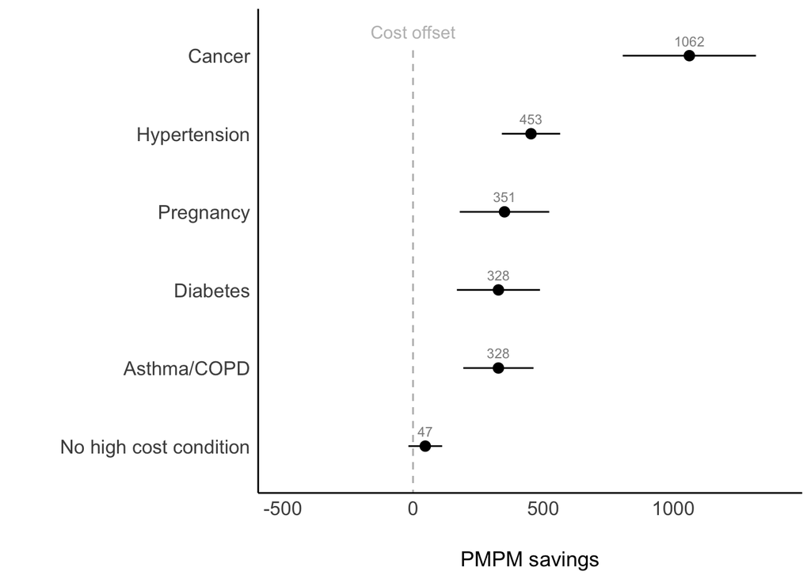

```r
# Make dotplot
ggplot(df_plot_hcc, aes(x=Estimate, xmin=lower, xmax=upper, y=hcc)) +
  geom_pointrange(position = position_dodge(width=0.5)) +
  geom_text(aes(x=Estimate, y=hcc, label = round(Estimate, 0), fill = NULL, vjust = -1), colour = "#8e8e8e", size = 3) +
  geom_segment(x = 0, xend=0, y=0, yend = 6.1, linetype = "dashed", color = "grey") +
  annotate(geom = "text", x=0, y=6.3, label = "Cost offset", hjust=0.5, color = "grey") +
  xlim(-500, 1400) +
  expand_limits(y = c(1, 6.5)) +
  theme_modern() +
  theme(legend.position = "bottom") +
  labs(
    x = "PMPM savings",
    y = "",
    fill = " "
  )
```

# 7 Therapy moderators

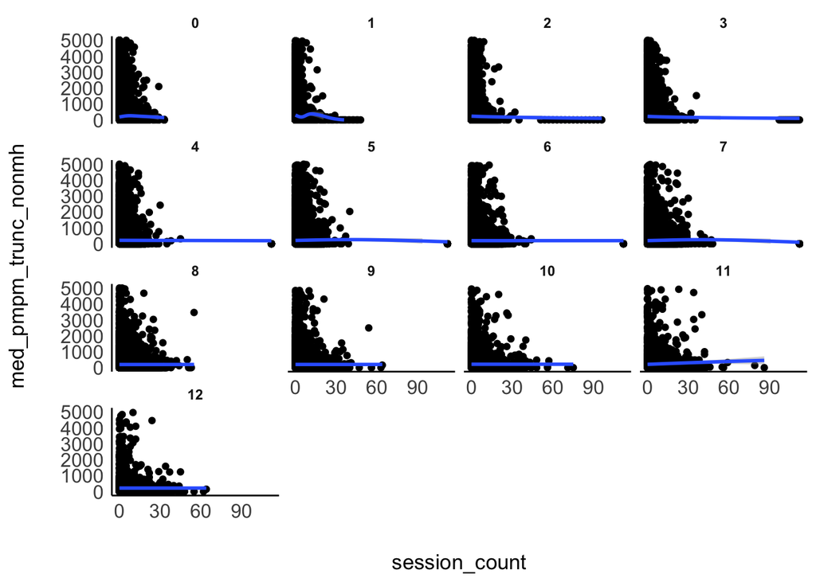

```r
# Calculate cumulative sessions
df_matched <- df_matched %>%
  group_by(carrier_member_id) %>%
  arrange(months) %>%
  mutate(
    session_count = case_when(
      spring_dummy == "Spring" ~ cumsum(spring_tx_count_month),
      spring_dummy == "Health Plan" ~ cumsum(carrier_tx_count_month)
    )
  ) %>%
  mutate(session_count_trunc = ifelse(session_count > 24, 24, session_count)) %>%
  mutate(session_count_total = max(session_count, na.rm=T))

# Let's look at non-mh spending only, since otherwise spending is complicated by spring spend not being included
ggplot(df_matched, aes(x=session_count, y = med_pmpm_trunc_nonmh)) +
  geom_point() +
  geom_smooth() +
  facet_wrap(.~ months_post) +
  theme_modern() +
  ylim(0, 5000)
```

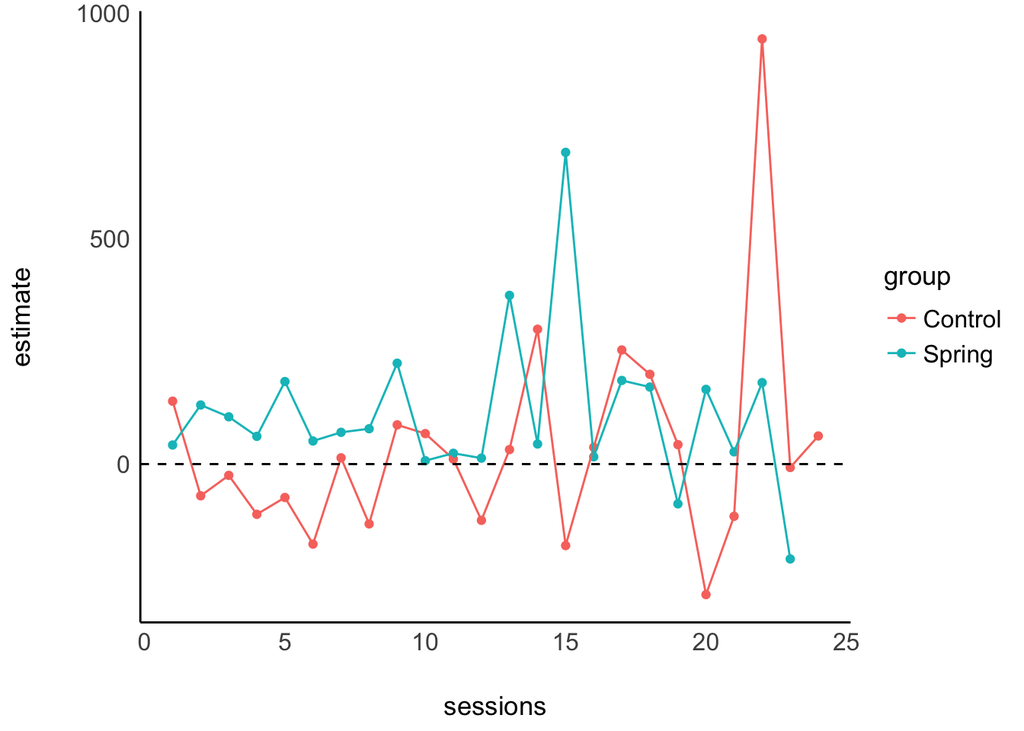

```r
# Allow some nonlinearity
df_matched <- df_matched %>%
  mutate(
    therapy_sessions_factor = case_when(
      session_count == 0 ~ "0",
      session_count > 0 & session_count <= 2 ~ "1 to 2",
      session_count > 2 & session_count <= 5 ~ "3 to 5",
      session_count > 5 & session_count <= 12 ~ "6 to 12",
      session_count > 12 ~ "13+"
    ),
    any_therapy = ifelse(session_count > 0, "yes", "no")
  ) %>%
  mutate(therapy_sessions_factor = factor(therapy_sessions_factor, levels = c("0", "1 to 2", "3 to 5", "6 to 12", "13+")))

m_sessions0 <- lmer(med_pmpm_trunc_nonmh ~ 0 + spring_dummy:phase + spring_dummy:as.factor(session_count_trunc) + as.factor(months_post):spring_dummy +
             (1 | carrier_member_id) +
             (1 | subclass_nn),
           weights = weights_nn,
           data = filter(df_matched))

m_sessions_numeric <- lmer(med_pmpm_trunc_nonmh ~ 0 + spring_dummy:phase + spring_dummy:session_count_trunc + as.factor(months_post):spring_dummy +
             (1 | carrier_member_id) +
             (1 | subclass_nn),
           weights = weights_nn,
           data = filter(df_matched))

df_sessions <- m_sessions0 %>%
  broom.mixed::tidy() %>%
  filter(str_detect(term, "session_count")) %>%
  #mutate(term = str_replace(term, "spring_dummy", "")) %>%
  mutate(group = ifelse(str_detect(term, "Health Plan"), "Control", "Spring")) %>%
  mutate(sessions = str_extract(term,  "\\)(.*)")) %>%
  mutate(sessions = str_replace(sessions, "\\)", "")) %>%
  mutate(sessions = as.numeric(sessions))

ggplot(df_sessions, aes(x=sessions, y=estimate, group=group, color=group)) +
  geom_point() +
  geom_line() +
  geom_hline(yintercept = 0, linetype = "dashed") +
  theme_modern()
```

```r
m_sessions1 <- lmer(med_pmpm_trunc_nonmh ~ 1 + spring_dummy + spring_dummy*phase +
                     as.factor(months_post) + as.factor(months_post)*spring_dummy +
                      any_therapy + session_count + session_count*spring_dummy +
             (1 | carrier_member_id) +
             (1 | subclass_nn),
           weights = weights_nn,
           data = df_matched)

m_sessions2 <- lmer(med_pmpm_trunc_nonmh ~ 1 + spring_dummy + spring_dummy*phase +
                     as.factor(months_post) + as.factor(months_post)*spring_dummy +
                      therapy_sessions_factor + therapy_sessions_factor*spring_dummy +
             (1 | carrier_member_id) +
             (1 | subclass_nn),
           weights = weights_nn,
           data = df_matched)

m_sessions3 <- lmer(med_pmpm_trunc_nonmh ~ 1 + spring_dummy + spring_dummy*phase +
                     as.factor(months_post) + as.factor(months_post)*spring_dummy +
                      therapy_sessions_factor +
             (1 | carrier_member_id) +
             (1 | subclass_nn),
           weights = weights_nn,
           data = df_matched)

tab_model(m_sessions1, m_sessions2,
          drop = c("months_post", "(Intercept)", "phase"),
          show.ci=F,
          show.icc = F,
          show.re.var = F,
          show.r2 = F,
          show.aic = T,
          dv.labels = c("Model 1", "Model 2"),
          show.se=T)
```

|  | Model 1 |  |  | Model 2 |  |  |
| --- | --- | --- | --- | --- | --- | --- |
| Predictors | Estimates | std. Error | p | Estimates | std. Error | p |
| spring dummy [Spring] | 4.88 | 21.66 | 0.822 | 4.98 | 21.66 | 0.818 |
| any therapy [yes] | 7.43 | 32.32 | 0.818 |  |  |  |
| session count | 0.50 | 3.45 | 0.884 |  |  |  |
| spring dummy [Spring] × session count | 0.53 | 4.55 | 0.907 |  |  |  |
| therapy sessions factor [1 to 2] |  |  |  | 60.43 | 36.18 | 0.095 |
| therapy sessions factor [3 to 5] |  |  |  | -60.65 | 44.00 | 0.168 |
| therapy sessions factor [6 to 12] |  |  |  | -47.35 | 47.54 | 0.319 |
| therapy sessions factor [13+] |  |  |  | 85.93 | 66.60 | 0.197 |
| spring dummy [Spring] × therapy sessions factor [1 to 2] |  |  |  | -99.11 | 123.63 | 0.423 |
| spring dummy [Spring] × therapy sessions factor [3 to 5] |  |  |  | 50.23 | 125.16 | 0.688 |
| spring dummy [Spring] × therapy sessions factor [6 to 12] |  |  |  | -5.85 | 124.50 | 0.962 |
| N | 13990 <sub>carrier_member_id</sub> |  |  | 13990 <sub>carrier_member_id</sub> |  |  |
|  | 4910 <sub>subclass_nn</sub> |  |  | 4910 <sub>subclass_nn</sub> |  |  |
| Observations | 257336 |  |  | 257336 |  |  |
| AIC | 4857846.002 |  |  | 4857791.675 |  |  |

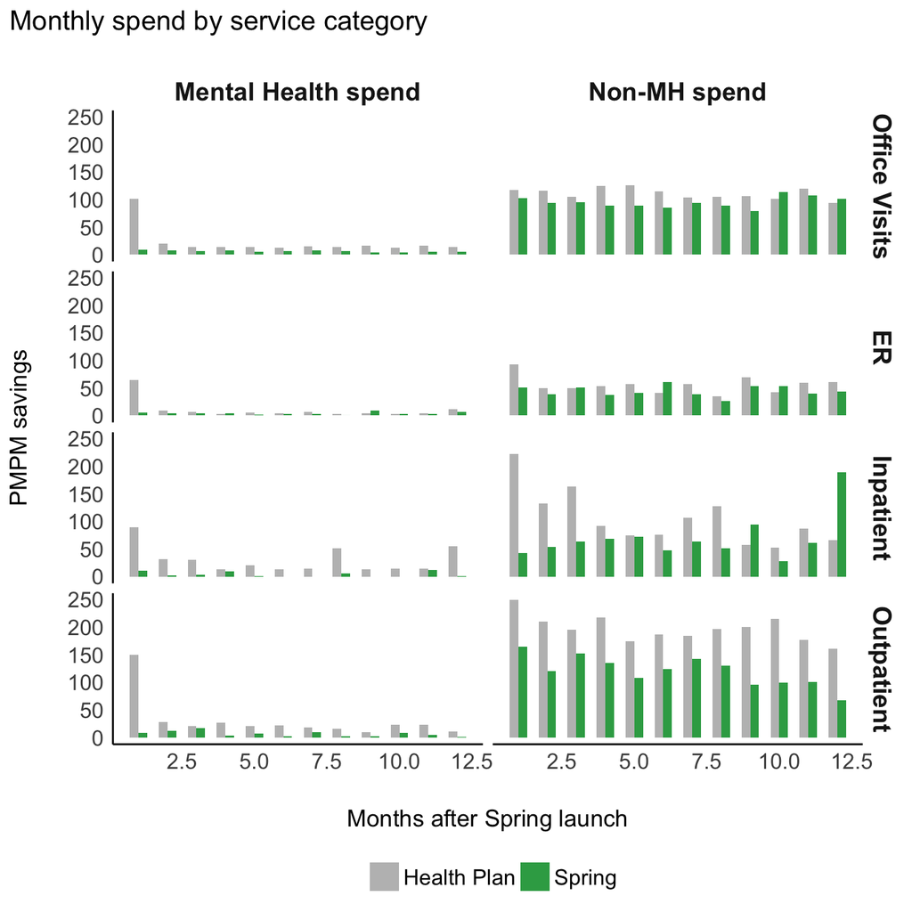

```r
df_monthly_spend <- df_matched %>%
  group_by(spring_dummy, months) %>%
  summarize(
    pmpm_mh_ov = mean(med_pmpm_trunc_ov_mh, na.rm=T),
    pmpm_mh_er = mean(med_pmpm_trunc_er_mh, na.rm=T),
    pmpm_mh_op = mean(med_pmpm_trunc_hosp_op_mh, na.rm=T),
    pmpm_mh_ip = mean(med_pmpm_trunc_ip_mh, na.rm=T),
    pmpm_mh_therapy = mean(med_pmpm_therapy_mh_net),

    pmpm_nonmh_ov = mean(med_pmpm_trunc_ov_nonmh, na.rm=T),
    pmpm_nonmh_er = mean(med_pmpm_trunc_er_nonmh, na.rm=T),
    pmpm_nonmh_op = mean(med_pmpm_trunc_hosp_op_nonmh, na.rm=T),
    pmpm_nonmh_ip = mean(med_pmpm_trunc_ip_nonmh, na.rm=T),
    pmpm_nonmh_therapy = mean(med_pmpm_therapy_nonmh)
    ) %>%
  filter(months <= 12) %>%
  filter(months > 0) %>%
  pivot_longer(
    cols = c(pmpm_mh_ov:pmpm_nonmh_therapy),
    names_prefix = "pmpm_",
    names_to = "spend_cat",
    values_to = "estimate"
    ) %>%
  mutate(
    mh_spend = ifelse(str_starts(spend_cat, "mh_*"), "mh", "non-MH"),
    category = str_replace(spend_cat, ".*_", "")
  ) %>%
  mutate(
    mh_spend = ifelse(mh_spend == "mh", "Mental Health spend", "Non-MH spend"),
    category = case_when(
      category == "er" ~ "ER",
      category == "ip" ~ "Inpatient",
      category == "op" ~ "Outpatient",
      category == "ov" ~ "Office Visits",
      category == "therapy" ~ "Therapy"
    )
  ) %>%
  mutate(category = factor(category, levels = c("Therapy", "Office Visits", "ER", "Inpatient", "Outpatient")))

# Category level
ggplot(filter(df_monthly_spend, category != "Therapy"), aes(x=months, y=estimate, group = spring_dummy, fill = spring_dummy)) +
  geom_bar(stat = "identity", width = 0.6, position=position_dodge()) +
  scale_fill_manual(values = rev(cc_colors)) +
  #geom_text(aes(x=total, y=chronic_condition, label = round(total, 0), fill = NULL, hjust = ifelse(total < 0, 1.1, -0.4)), colour = "#8e8e8e", size = 3, data = df_labels) +
  #expand_limits(x=c(0, 1.1*max(df_labels$total))) +
  theme_modern() +
  facet_grid(rows=vars(category), cols=vars(mh_spend), scales = "fixed") +
  theme(legend.position = "bottom") +
  theme(strip.text = element_text(size = 14)) +
  labs(
    title = "Monthly spend by service category",
    x = "Months after Spring launch",
    y = "PMPM savings",
    fill = " "
  )
```

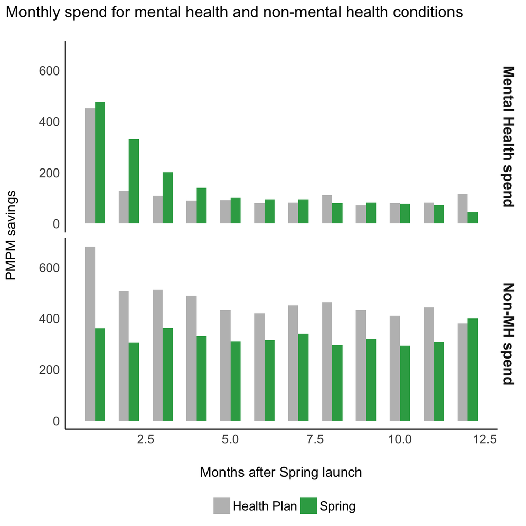

```r
# MH vs non-MH
df_monthly_spend %>%
  group_by(spring_dummy, months, mh_spend) %>%
  summarize(estimate = sum(estimate, na.rm=T)) %>%
  # Plot
  ggplot(., aes(x=months, y=estimate, group = spring_dummy, fill = spring_dummy)) +
  geom_bar(stat = "identity", width = 0.6, position=position_dodge()) +
  scale_fill_manual(values = rev(cc_colors)) +
  #geom_text(aes(x=total, y=chronic_condition, label = round(total, 0), fill = NULL, hjust = ifelse(total < 0, 1.1, -0.4)), colour = "#8e8e8e", size = 3, data = df_labels) +
  #expand_limits(x=c(0, 1.1*max(df_labels$total))) +
  theme_modern() +
  facet_grid(rows=vars(mh_spend), scales = "fixed") +
  theme(legend.position = "bottom") +
  theme(strip.text = element_text(size = 14)) +
  labs(
    title = "Monthly spend for mental health and non-mental health conditions",
    x = "Months after Spring launch",
    y = "PMPM savings",
    fill = " "
  )
```

# 8 ROI

## 8.1 Calculate ROI

- Note: participant-year ROI multiple is too high because it is currently based on incomplete fees.

```r
df_roi <- df_matched %>%
  filter(spring_dummy == "Spring") %>%
  filter(month_year == first_spring_tx_date) %>%
  mutate(months_treated = interval(first_spring_tx_date, spring_end_date) %/% months(1) + 1) %>%
  group_by(months_treated) %>%
  summarize(n = n_distinct(carrier_member_id)) %>%
  mutate(
    member_months_treated = n*months_treated,
    month_roi_gross = -1*n*months_treated*summary(m1_gross)$coefficients["spring_dummySpring:phasepost_tx", 1])
mean_months_treated <- sum(df_roi$member_months_treated)/sum(df_roi$n)


# First program year net savings %
deltamethod(m1_net, "0 = (6.5*b4) / ((12-6.5)*df_plot_total$estimate[1] + 6.5*(df_plot_total$estimate[2]))") # (PMPM savings / total control group spend)
```

```
##
##                                                                                   Term
##  0 = (6.5*b4) / ((12-6.5)*df_plot_total$estimate[1] + 6.5*(df_plot_total$estimate[2]))
##  Estimate Std. Error    z Pr(>|z|) 2.5 % 97.5 %
##      0.15     0.0255 5.91   <0.001 0.101    0.2
##
## Columns: term, estimate, std.error, statistic, p.value, conf.low, conf.high
```

```r
# First Program-year PMPY
deltamethod(m1_net, "0 = -1 * b4 * mean_months_treated")
```

```
##
##                               Term Estimate Std. Error     z Pr(>|z|) 2.5 %
##  0 = -1 * b4 * mean_months_treated    -1029        174 -5.91   <0.001 -1370
##  97.5 %
##    -687
##
## Columns: term, estimate, std.error, statistic, p.value, conf.low, conf.high
```

```r
# Program-year ROI multiple
deltamethod(m1_net, "0 = (1 + (-1*b4 * sum(df_roi$member_months_treated)) / total_invoiced)")
```

```
##
##                                                                    Term
##  0 = (1 + (-1*b4 * sum(df_roi$member_months_treated)) / total_invoiced)
##  Estimate Std. Error     z Pr(>|z|) 2.5 % 97.5 %
##     -1.85      0.144 -12.9   <0.001 -2.13  -1.57
##
## Columns: term, estimate, std.error, statistic, p.value, conf.low, conf.high
```

# 9 Sensitivity analysis

## 9.1 GLM with design weights - alternate specification of main effect weights

Multilevel models with design weights aren’t super well-studied. Here we use an alternate specification using design weights–a common approach–and find much the same result.

```r
# Sensitivity - GLM with design weights
design_test <- svydesign(
  id = ~ subclass_nn + carrier_member_id, # members nested in customers. Order matters in this equation.
  weights = ~weights_nn,
  data = df_matched)

glm_design_weights <- svyglm(med_pmpm_trunc_net ~ 1 + spring_dummy + spring_dummy*phase,
                design = design_test)

summary(glm_design_weights)
```

```
##
## Call:
## svyglm(formula = med_pmpm_trunc_net ~ 1 + spring_dummy + spring_dummy *
##     phase, design = design_test)
##
## Survey design:
## svydesign(id = ~subclass_nn + carrier_member_id, weights = ~weights_nn,
##     data = df_matched)
##
## Coefficients:
##                                 Estimate Std. Error t value Pr(>|t|)
## (Intercept)                       462.88      15.72  29.439  < 2e-16 ***
## spring_dummySpring                 11.92      19.73   0.604    0.546
## phasepost_tx                      341.80      22.99  14.866  < 2e-16 ***
## spring_dummySpring:phasepost_tx  -163.91      31.53  -5.199 2.09e-07 ***
## ---
## Signif. codes:  0 '***' 0.001 '**' 0.01 '*' 0.05 '.' 0.1 ' ' 1
##
## (Dispersion parameter for gaussian family taken to be 10639311)
##
## Number of Fisher Scoring iterations: 2
```

## 9.2 Trajectories

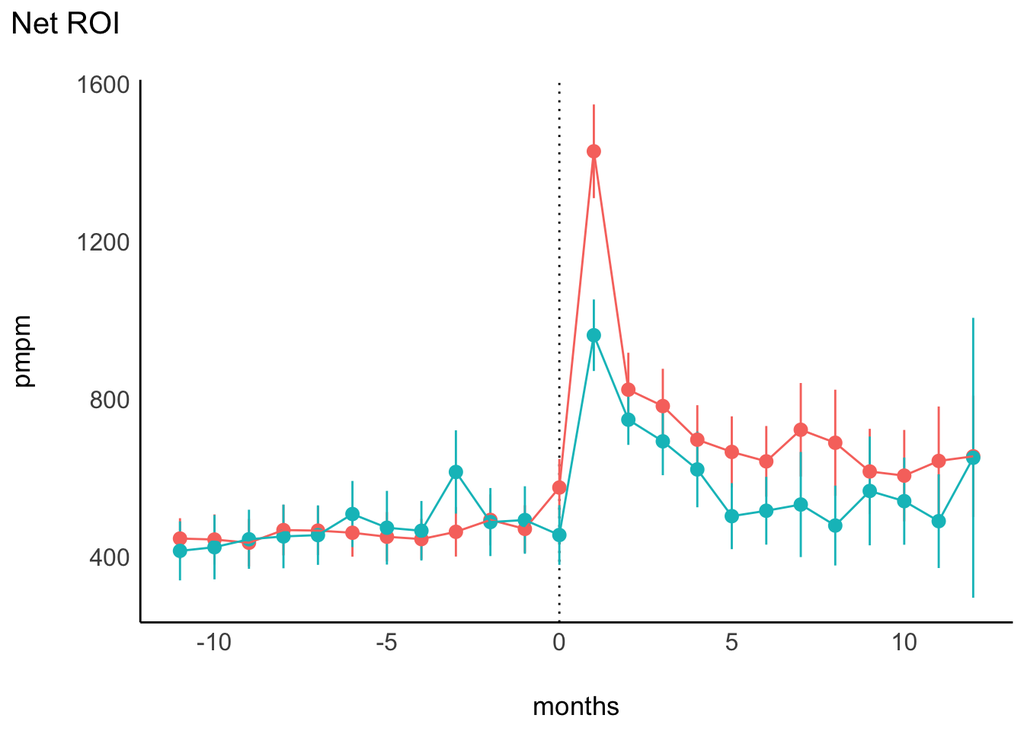

```r
library(splines)

# Fit models
m1_spline <- lmer(med_pmpm_trunc_net ~ 1 + spring_dummy + spring_dummy*phase +
                    spring_dummy*(ns(months_post, df = 4)) +
                    (1 | carrier_member_id) +
                    (1 | subclass_nn),
                  weights = weights_nn,
                  data = df_matched)

df_pred <- df_matched %>%
  distinct(spring_dummy, phase, months, months_post)

  df_plot_splines <- predictions(
    m1_spline,
    newdata = df_pred,
    re.form = ~0)


# Plot raw
df_matched %>%
  group_by(spring_dummy, months) %>%
  summarize(
    pmpm = mean(med_pmpm_trunc_net, na.rm=T),
    sd = sd(med_pmpm_trunc_net, na.rm=T),
    n = n_distinct(carrier_member_id),
    se = sd/sqrt(n)
    ) %>%
  filter(months <= 12) %>%
  ggplot(., aes(x=months, y=pmpm, ymin = pmpm - 1.96*se, ymax = pmpm + 1.96*se, group = spring_dummy, color=spring_dummy)) +
  geom_vline(xintercept = 0, linetype = "dotted") +
  geom_pointrange() +
  geom_line() +
  theme_modern() +
  theme(
    legend.position = "none",
    strip.text.x = element_blank()
    ) +
  labs(title = "Net ROI")
```

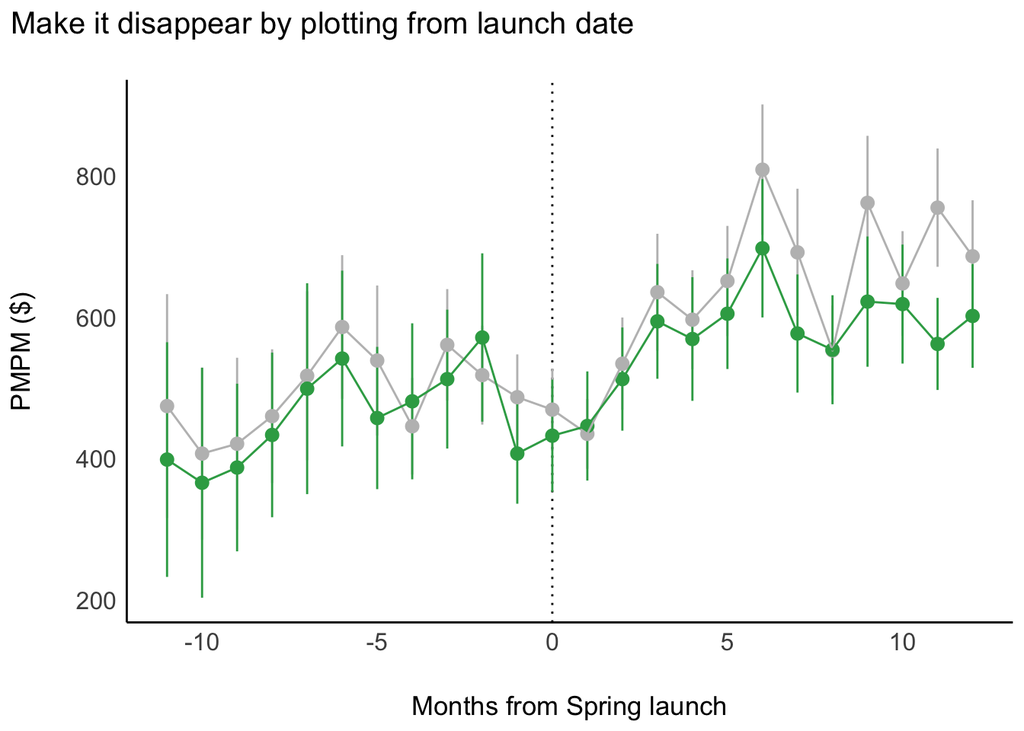

```r
## Make it disappear by plotting from launch date
## Approximate net ROI
df_matched %>%
  mutate(months_from_launch = interval(spring_start_date, month_year) %/% months(1) + 1) %>%
  group_by(spring_dummy, months_from_launch) %>%
  summarize(
    pmpm = mean(med_pmpm_trunc_net, na.rm=T),
    sd = sd(med_pmpm_trunc_net, na.rm=T),
    n = n_distinct(carrier_member_id),
    se = sd/sqrt(n)
    ) %>%
  filter(months_from_launch <= 12) %>%
  ggplot(., aes(x=months_from_launch, y=pmpm, ymin = pmpm - 1.96*se, ymax = pmpm + 1.96*se, group = spring_dummy, color=spring_dummy)) +
  geom_vline(xintercept = 0, linetype = "dotted") +
  geom_pointrange() +
  geom_line() +
  scale_color_manual(values = rev(cc_colors), labels = c("Control", "Spring Health")) +
  theme_modern() +
  theme(
    legend.position = "none",
    strip.text.x = element_blank()
    ) +
  labs(
    x = "Months from Spring launch",
    y = "PMPM ($)",
    title = "Make it disappear by plotting from launch date")
```

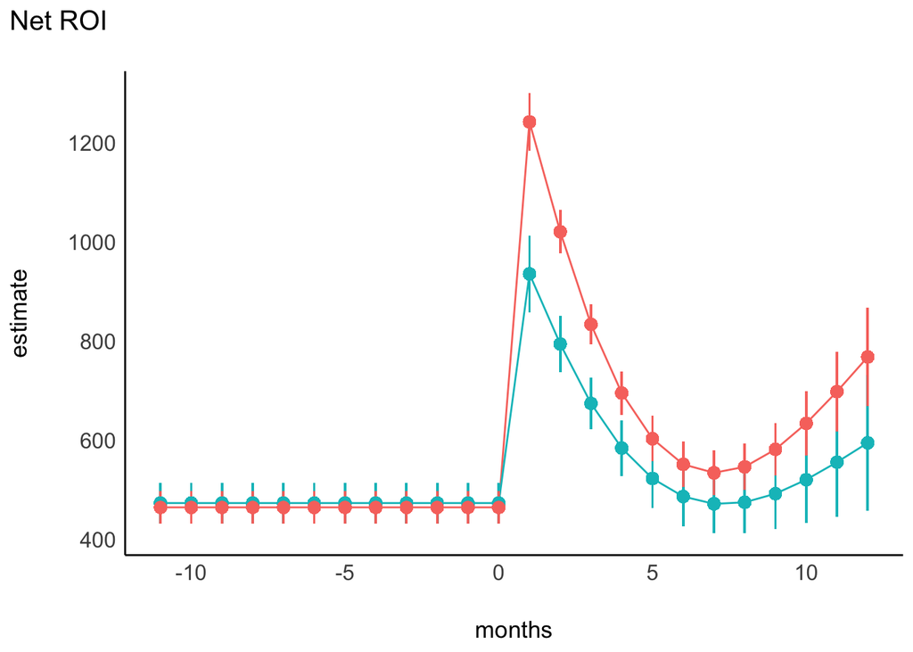

```r
# Plot splines
ggplot(df_plot_splines, aes(x=months, y=estimate, ymin = conf.low, ymax=conf.high, group = spring_dummy, color=spring_dummy)) +
  geom_line() +
  geom_pointrange() +
  theme_modern() +
  theme(
    legend.position = "none",
    strip.text.x = element_blank()
  ) +
    labs(title = "Net ROI")
```

## 9.3 Do session counts differ for individuals with high cost conditions?

```r
df_cc_table <- df_match_table %>%
  mutate(cc_group = case_when(
    cc_cancer == "yes" ~ "Cancer",
    cc_hypertension == "yes" ~ "Hypertension",
    excl_pregnancy == "yes" ~ "Pregnancy",
    cc_diabetes == "yes" ~ "Diabetes",
    cc_asthma_copd == "yes" ~ "Asthma/COPD",
    TRUE ~ "No chronic condition"
  ))

table1( ~ age_at_index + member_sex + dx_imputed + risk_score_dx + months_diagnosed + any_bh + bh_if_engaged | spring_dummy*cc_group,
        overall = T,
        footnote = "This table is based on raw values. In cases where 2 matches were not achieved, weights were applied.",
        data=df_cc_table)
```

|  | Control Asthma/COPD (N=486) | Control Cancer (N=300) | Control Diabetes (N=186) | Control Hypertension (N=1835) | Control No chronic condition (N=5901) | Control Pregnancy (N=375) | Spring Health Asthma/COPD (N=282) | Spring Health Cancer (N=130) | Spring Health Diabetes (N=109) | Spring Health Hypertension (N=775) | Spring Health No chronic condition (N=3386) | Spring Health Pregnancy (N=225) | TRUE Asthma/COPD (N=768) | TRUE Cancer (N=430) | TRUE Diabetes (N=295) | TRUE Hypertension (N=2610) | TRUE No chronic condition (N=9287) | TRUE Pregnancy (N=600) |
| --- | --- | --- | --- | --- | --- | --- | --- | --- | --- | --- | --- | --- | --- | --- | --- | --- | --- | --- |
| age_at_index |  |  |  |  |  |  |  |  |  |  |  |  |  |  |  |  |  |  |
| Mean (SD) | 33.3 (14.3) | 50.3 (11.0) | 45.0 (12.7) | 47.7 (10.7) | 33.7 (13.2) | 31.5 (5.11) | 36.2 (11.4) | 48.6 (11.0) | 42.4 (11.5) | 46.2 (10.2) | 35.2 (11.2) | 32.6 (4.75) | 34.4 (13.4) | 49.8 (11.0) | 44.1 (12.3) | 47.3 (10.5) | 34.2 (12.6) | 31.9 (5.01) |
| Median [Min, Max] | 32.0 [5.00, 66.0] | 51.0 [9.00, 75.0] | 47.5 [9.00, 72.0] | 49.0 [12.0, 85.0] | 33.0 [5.00, 74.0] | 32.0 [17.0, 44.0] | 36.0 [6.00, 65.0] | 50.5 [21.0, 73.0] | 42.0 [16.0, 64.0] | 46.0 [19.0, 71.0] | 34.0 [6.00, 74.0] | 33.0 [17.0, 51.0] | 34.0 [5.00, 66.0] | 51.0 [9.00, 75.0] | 46.0 [9.00, 72.0] | 48.0 [12.0, 85.0] | 33.0 [5.00, 74.0] | 32.0 [17.0, 51.0] |
| member_sex |  |  |  |  |  |  |  |  |  |  |  |  |  |  |  |  |  |  |
| female | 319 (65.6%) | 209 (69.7%) | 120 (64.5%) | 1082 (59.0%) | 3775 (64.0%) | 373 (99.5%) | 197 (69.9%) | 98 (75.4%) | 73 (67.0%) | 493 (63.6%) | 2195 (64.8%) | 225 (100%) | 516 (67.2%) | 307 (71.4%) | 193 (65.4%) | 1575 (60.3%) | 5970 (64.3%) | 598 (99.7%) |
| male | 167 (34.4%) | 91 (30.3%) | 66 (35.5%) | 753 (41.0%) | 2126 (36.0%) | 2 (0.5%) | 85 (30.1%) | 32 (24.6%) | 36 (33.0%) | 282 (36.4%) | 1191 (35.2%) | 0 (0%) | 252 (32.8%) | 123 (28.6%) | 102 (34.6%) | 1035 (39.7%) | 3317 (35.7%) | 2 (0.3%) |
| dx_imputed |  |  |  |  |  |  |  |  |  |  |  |  |  |  |  |  |  |  |
| mood | 98 (20.2%) | 71 (23.7%) | 65 (34.9%) | 440 (24.0%) | 1254 (21.3%) | 63 (16.8%) | 66 (23.4%) | 32 (24.6%) | 24 (22.0%) | 198 (25.5%) | 672 (19.8%) | 39 (17.3%) | 164 (21.4%) | 103 (24.0%) | 89 (30.2%) | 638 (24.4%) | 1926 (20.7%) | 102 (17.0%) |
| anxiety | 361 (74.3%) | 205 (68.3%) | 103 (55.4%) | 1291 (70.4%) | 4283 (72.6%) | 302 (80.5%) | 202 (71.6%) | 91 (70.0%) | 81 (74.3%) | 527 (68.0%) | 2516 (74.3%) | 181 (80.4%) | 563 (73.3%) | 296 (68.8%) | 184 (62.4%) | 1818 (69.7%) | 6799 (73.2%) | 483 (80.5%) |
| sud | 8 (1.6%) | 16 (5.3%) | 9 (4.8%) | 73 (4.0%) | 161 (2.7%) | 3 (0.8%) | 6 (2.1%) | 5 (3.8%) | 2 (1.8%) | 34 (4.4%) | 89 (2.6%) | 3 (1.3%) | 14 (1.8%) | 21 (4.9%) | 11 (3.7%) | 107 (4.1%) | 250 (2.7%) | 6 (1.0%) |
| other | 19 (3.9%) | 8 (2.7%) | 9 (4.8%) | 31 (1.7%) | 203 (3.4%) | 7 (1.9%) | 8 (2.8%) | 2 (1.5%) | 2 (1.8%) | 16 (2.1%) | 109 (3.2%) | 2 (0.9%) | 27 (3.5%) | 10 (2.3%) | 11 (3.7%) | 47 (1.8%) | 312 (3.4%) | 9 (1.5%) |
| risk_score_dx |  |  |  |  |  |  |  |  |  |  |  |  |  |  |  |  |  |  |
| Mean (SD) | 1.75 (3.32) | 5.18 (8.25) | 2.36 (3.25) | 1.95 (3.99) | 0.838 (2.38) | 2.15 (2.18) | 1.55 (2.64) | 5.68 (8.07) | 2.25 (2.83) | 2.31 (4.63) | 0.801 (2.27) | 2.42 (3.04) | 1.68 (3.08) | 5.33 (8.19) | 2.32 (3.10) | 2.05 (4.19) | 0.824 (2.34) | 2.25 (2.54) |
| Median [Min, Max] | 1.06 [0.102, 32.8] | 1.79 [0.155, 54.7] | 1.22 [0.188, 26.3] | 0.604 [0.155, 54.1] | 0.306 [0.102, 49.6] | 0.602 [0.238, 17.0] | 1.18 [0.155, 30.6] | 3.14 [0.155, 46.5] | 1.21 [0.155, 17.0] | 0.604 [0.155, 50.4] | 0.348 [0.102, 48.8] | 0.556 [0.271, 26.1] | 1.11 [0.102, 32.8] | 2.53 [0.155, 54.7] | 1.22 [0.155, 26.3] | 0.604 [0.155, 54.1] | 0.306 [0.102, 49.6] | 0.602 [0.238, 26.1] |
| months_diagnosed |  |  |  |  |  |  |  |  |  |  |  |  |  |  |  |  |  |  |
| Mean (SD) | 6.87 (3.42) | 7.12 (3.24) | 6.31 (3.30) | 6.73 (3.37) | 6.43 (3.42) | 6.76 (3.35) | 7.04 (3.37) | 6.67 (3.50) | 6.61 (3.37) | 6.58 (3.45) | 6.45 (3.48) | 6.60 (3.50) | 6.93 (3.40) | 6.98 (3.33) | 6.42 (3.33) | 6.69 (3.39) | 6.44 (3.45) | 6.70 (3.41) |
| Median [Min, Max] | 7.00 [1.00, 12.0] | 7.00 [1.00, 12.0] | 6.00 [1.00, 12.0] | 7.00 [1.00, 12.0] | 6.00 [1.00, 12.0] | 7.00 [1.00, 12.0] | 7.00 [1.00, 12.0] | 7.00 [1.00, 12.0] | 6.00 [1.00, 12.0] | 6.00 [1.00, 12.0] | 6.00 [1.00, 12.0] | 7.00 [1.00, 12.0] | 7.00 [1.00, 12.0] | 7.00 [1.00, 12.0] | 6.00 [1.00, 12.0] | 7.00 [1.00, 12.0] | 6.00 [1.00, 12.0] | 7.00 [1.00, 12.0] |
| any_bh |  |  |  |  |  |  |  |  |  |  |  |  |  |  |  |  |  |  |
| no | 322 (66.3%) | 215 (71.7%) | 124 (66.7%) | 1400 (76.3%) | 3712 (62.9%) | 216 (57.6%) | 0 (0%) | 0 (0%) | 0 (0%) | 0 (0%) | 0 (0%) | 0 (0%) | 322 (41.9%) | 215 (50.0%) | 124 (42.0%) | 1400 (53.6%) | 3712 (40.0%) | 216 (36.0%) |
| yes | 164 (33.7%) | 85 (28.3%) | 62 (33.3%) | 435 (23.7%) | 2189 (37.1%) | 159 (42.4%) | 282 (100%) | 130 (100%) | 109 (100%) | 775 (100%) | 3386 (100%) | 225 (100%) | 446 (58.1%) | 215 (50.0%) | 171 (58.0%) | 1210 (46.4%) | 5575 (60.0%) | 384 (64.0%) |
| bh_if_engaged |  |  |  |  |  |  |  |  |  |  |  |  |  |  |  |  |  |  |
| Mean (SD) | 8.27 (9.12) | 7.36 (7.17) | 6.27 (7.43) | 6.17 (7.72) | 7.47 (8.25) | 7.06 (9.14) | 5.52 (4.47) | 4.88 (4.26) | 4.85 (4.36) | 4.34 (4.44) | 4.71 (4.94) | 4.08 (3.68) | 6.54 (6.70) | 5.87 (5.71) | 5.37 (5.69) | 5.00 (5.90) | 5.79 (6.58) | 5.32 (6.67) |
| Median [Min, Max] | 5.00 [1.00, 56.0] | 6.00 [1.00, 34.0] | 3.00 [1.00, 48.0] | 3.00 [1.00, 62.0] | 4.00 [1.00, 86.0] | 4.00 [1.00, 79.0] | 5.00 [1.00, 27.0] | 3.00 [1.00, 20.0] | 3.00 [1.00, 21.0] | 3.00 [1.00, 42.0] | 3.00 [1.00, 112] | 3.00 [1.00, 29.0] | 5.00 [1.00, 56.0] | 4.00 [1.00, 34.0] | 3.00 [1.00, 48.0] | 3.00 [1.00, 62.0] | 4.00 [1.00, 112] | 3.00 [1.00, 79.0] |
| Missing | 322 (66.3%) | 215 (71.7%) | 124 (66.7%) | 1400 (76.3%) | 3712 (62.9%) | 216 (57.6%) | 0 (0%) | 0 (0%) | 0 (0%) | 0 (0%) | 0 (0%) | 0 (0%) | 322 (41.9%) | 215 (50.0%) | 124 (42.0%) | 1400 (53.6%) | 3712 (40.0%) | 216 (36.0%) |

This table is based on raw values. In cases where 2 matches were not achieved, weights were applied.

## 9.4 Participant-year trajectories

```r
m_1yr_participant <- lmer(med_pmpm_trunc_net ~ 1 + spring_dummy + as.factor(months_post) +
                          spring_dummy*as.factor(months_post) +
                             (1 | carrier_member_id) +
                             (1 | subclass_nn),
                           weights = weights_nn,
                           data = df_matched)

tab_model(m_1yr_participant, show.ci=F, show.se=T)
```

|  | med pmpm trunc net |  |  |
| --- | --- | --- | --- |
| Predictors | Estimates | std. Error | p |
| (Intercept) | 464.32 | 16.66 | **<0.001** |
| spring dummy [Spring] | 8.56 | 22.46 | 0.703 |
| months post1 | 949.51 | 33.48 | **<0.001** |
| months post2 | 359.80 | 34.05 | **<0.001** |
| months post3 | 300.26 | 35.55 | **<0.001** |
| months post4 | 198.88 | 37.23 | **<0.001** |
| months post5 | 152.06 | 39.41 | **<0.001** |
| months post6 | 137.42 | 42.49 | **0.001** |
| months post7 | 220.08 | 45.60 | **<0.001** |
| months post8 | 170.64 | 50.13 | **0.001** |
| months post9 | 122.30 | 55.50 | **0.028** |
| months post10 | 122.26 | 62.18 | **0.049** |
| months post11 | 137.27 | 72.88 | 0.060 |
| months post12 | 135.28 | 90.81 | 0.136 |
| spring dummy [Spring] × months post1 | -458.21 | 56.43 | **<0.001** |
| spring dummy [Spring] × months post2 | -86.71 | 57.44 | 0.131 |
| spring dummy [Spring] × months post3 | -89.64 | 60.02 | 0.135 |
| spring dummy [Spring] × months post4 | -67.23 | 62.78 | 0.284 |
| spring dummy [Spring] × months post5 | -145.51 | 66.86 | **0.030** |
| spring dummy [Spring] × months post6 | -120.15 | 72.35 | 0.097 |
| spring dummy [Spring] × months post7 | -171.20 | 78.14 | **0.028** |
| spring dummy [Spring] × months post8 | -185.77 | 86.26 | **0.031** |
| spring dummy [Spring] × months post9 | -50.84 | 95.24 | 0.593 |
| spring dummy [Spring] × months post10 | -79.69 | 105.58 | 0.450 |
| spring dummy [Spring] × months post11 | -146.24 | 124.18 | 0.239 |
| spring dummy [Spring] × months post12 | 15.97 | 157.48 | 0.919 |
| Random Effects |  |  |  |
| σ<sup>2</sup> | 9365227.59 |  |  |
| τ<sub>00</sub> <sub>carrier_member_id</sub> | 781445.02 |  |  |
| τ<sub>00</sub> <sub>subclass_nn</sub> | 488093.93 |  |  |
| ICC | 0.12 |  |  |
| N <sub>carrier_member_id</sub> | 13990 |  |  |
| N <sub>subclass_nn</sub> | 4910 |  |  |
| Observations | 257326 |  |  |
| Marginal R<sup>2</sup> / Conditional R<sup>2</sup> | 0.004 / 0.123 |  |  |

```r
# Get PPPY in dollars
hypotheses(m_1yr_participant, hypothesis = "b15 + b16 + b17 + b18 + b19 + b20 + b21 + b22 + b23 + b24 + b25 + b26 = 0")
```

```
##
##                                                                       Term
##  b15 + b16 + b17 + b18 + b19 + b20 + b21 + b22 + b23 + b24 + b25 + b26 = 0
##  Estimate Std. Error     z Pr(>|z|) 2.5 % 97.5 %
##     -1585        373 -4.25   <0.001 -2317   -854
##
## Columns: term, estimate, std.error, statistic, p.value, conf.low, conf.high
```

```r
# Get PPPY in pct
hypotheses(m_1yr_participant, hypothesis = "(b15 + b16 + b17 + b18 + b19 + b20 + b21 + b22 + b23 + b24 + b25 + b26) /
          (b1*12 + b3 + b4 + b5 + b6 + b7 + b8 + b9 + b10 + b11 + b12 + b13 + b14)  = 0")
```

```
##
##                                                                                                                                                                Term
##  (b15 + b16 + b17 + b18 + b19 + b20 + b21 + b22 + b23 + b24 + b25 + b26) /\n          (b1*12 + b3 + b4 + b5 + b6 + b7 + b8 + b9 + b10 + b11 + b12 + b13 + b14)  = 0
##  Estimate Std. Error     z Pr(>|z|)  2.5 % 97.5 %
##    -0.185     0.0418 -4.42   <0.001 -0.267 -0.103
##
## Columns: term, estimate, std.error, statistic, p.value, conf.low, conf.high
```

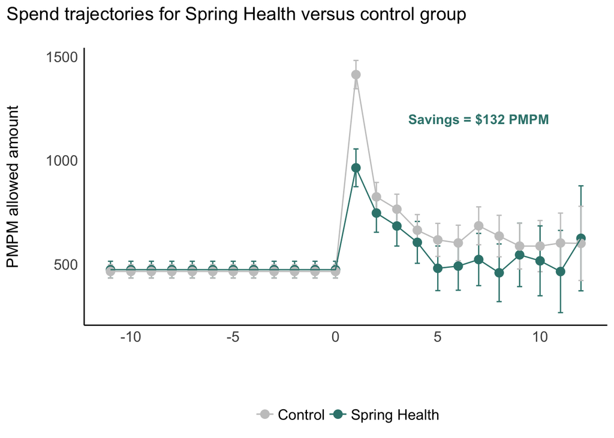

```r
# Plot
df_plot_participant_year <- df_matched %>%
  ungroup() %>%
  distinct(spring_dummy, months, months_post)

df_plot_participant_year <- predictions(m_1yr_participant, newdata = df_plot_participant_year,  re.form = ~0)
monthly_avg_did <- pull(hypotheses(m_1yr_participant, hypothesis = "b15 + b16 + b17 + b18 + b19 + b20 + b21 + b22 + b23 + b24 + b25 + b26 = 0")[2]/12)

# Overall with error bars
ggplot(df_plot_participant_year, aes(x=months, y=estimate, ymin=conf.low, ymax=conf.high, group = spring_dummy, color = spring_dummy)) +
  geom_errorbar(width = 0.25) +
  geom_point(size=3) +
  geom_line() +
  scale_color_manual(values = color_scheme, labels = c("Control", "Spring Health")) +
  annotate(geom = "text", x=7, y=1200, label = paste0("Savings = $", round(-1*monthly_avg_did, 0), " PMPM"), color = "#37837c", fontface = "bold") +
  theme_modern() +
  theme(legend.position = "bottom") +
  labs(
    title = "Spend trajectories for Spring Health versus control group",
    x = "",
    y = "PMPM allowed amount",
    color = ""
  )
```

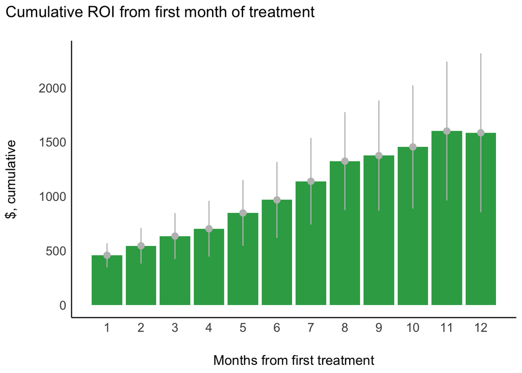

```r
# Plot cumulative ROI
generate_b_string <- function(b) {
  # Generate the sequence of elements
  elements <- sapply(1:b, function(i) paste("b", 15+i-1, sep=""))

  # Combine elements into a single string with " + " as separator
  result_string <- paste(elements, collapse = " + ")

  return(result_string)
}
net_fun <- function(x) {hypotheses(m_1yr_participant, hypothesis = paste0(generate_b_string(x), "= 0"))}

df_plot_cumulative <- data.frame(months_post = seq(1, 12, 1)) %>%
  rowwise() %>%
  mutate(
    net_cumulative = -1*net_fun(months_post)[[2]],
    lb = -1*net_fun(months_post)[[6]],
    ub = -1*net_fun(months_post)[[7]]
) %>%
  ungroup() %>%
  data.frame()

# people like bar plots
ggplot(df_plot_cumulative, aes(x=months_post, y=net_cumulative, ymin=lb, ymax=ub)) +
  geom_bar(stat = "identity", fill = "#34a853") +
  geom_pointrange(color = "grey") +
  theme_modern() +
  scale_x_continuous(breaks = seq(1,12,1)) +
  labs(
    title = "Cumulative ROI from first month of treatment",
    x = "Months from first treatment",
    y = "$, cumulative"
  )
```

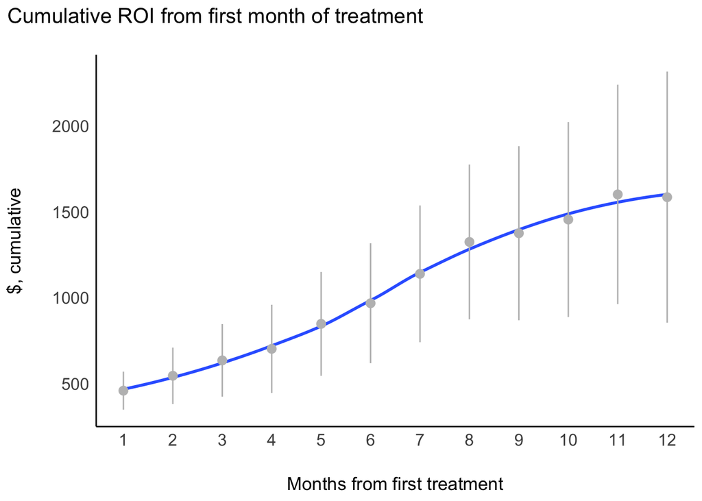

```r
# ... but line plots are better for understanding the data
ggplot(df_plot_cumulative, aes(x=months_post, y=net_cumulative, ymin=lb, ymax=ub)) +
  geom_smooth(se=FALSE) +
  geom_pointrange(color = "grey") +
  theme_modern() +
  scale_x_continuous(breaks = seq(1,12,1)) +
  labs(
    title = "Cumulative ROI from first month of treatment",
    x = "Months from first treatment",
    y = "$, cumulative"
  )
```

## 9.5 Stratification by BH treatment

Do we get more savings versus the control group that did not engage in BH treatment? No.

We have more net savings on mental health spend compared to the control group members that engaged in MH care. Physical health savings are the same in both groups. Don’t love that finding as it undermines the narrative the MH treatment provides physical health savings.

Based on sessions alone, I think we can make the argument that we have more efficient care than the control group, which dovetails with what Dan Harrah was saying about Lyra’s length of care in our ROI narrative meeting. We have already shown that we get gold standard clinical outcomes due to MBC, so we can argue that at Spring people get the right amount of care and aren’t trapped in therapy endlessly after they don’t need it. But I worry that Lyra could make the argument that 4 sessions is not a full course of care and we aren’t delivering the care our patients need. Not sure how much to worry about what Lyra would say, though.

```r
# Make 3 groups
df_match_table <- df_match_table %>%
  mutate(spring_dummy_stratified = case_when(
    spring_dummy == "Control" & any_bh == "no" ~ "Control, no BH appt",
    spring_dummy == "Control" & any_bh == "yes" ~ "Control group with BH appt",
    spring_dummy == "Spring Health" ~ "Spring Health"
  ))

table1( ~ any_bh + session_count_total | spring_dummy_stratified,
        overall = F,
        footnote = "This table is based on raw values. In cases where 2 matches were not achieved, weights were applied.",
        data=df_match_table)
```

|  | Control group with BH appt (N=3094) | Control, no BH appt (N=5989) | Spring Health (N=4907) |
| --- | --- | --- | --- |
| any_bh |  |  |  |
| yes | 3094 (100%) | 0 (0%) | 4907 (100%) |
| no | 0 (0%) | 5989 (100%) | 0 (0%) |
| session_count_total |  |  |  |
| Mean (SD) | 7.28 (8.24) | 0 (0) | 4.68 (4.76) |
| Median [Min, Max] | 4.00 [1.00, 86.0] | 0 [0, 0] | 3.00 [1.00, 112] |

This table is based on raw values. In cases where 2 matches were not achieved, weights were applied.

```r
# Group by BH usage
df_matched <- df_matched %>%
  group_by(carrier_member_id) %>%
  arrange(months) %>%
  mutate(
    therapy_sessions_total = sum(spring_therapist_count_month, carrier_therapist_count_month, na.rm=T),
    session_count_total = sum(spring_tx_count_month, carrier_tx_count_month, na.rm=T)
  ) %>%
  mutate(any_bh = ifelse(session_count_total > 0, "yes", "no")) %>%
  mutate(spring_dummy_stratified = case_when(
    spring_dummy == "Health Plan" & any_bh == "no" ~ "Control, no BH appt",
    spring_dummy == "Health Plan" & any_bh == "yes" ~ "Control, yes BH appt",
    spring_dummy == "Spring" ~ "Spring Health"
  )) %>%
  mutate(spring_dummy_stratified = factor(spring_dummy_stratified, levels = c("Spring Health", "Control, no BH appt", "Control, yes BH appt")))

df_matched <- df_matched %>%
  mutate(session_count_trunc = ifelse(session_count_total > 24, 24, session_count_total))


m1_bh_overall <- lmer(med_pmpm_trunc_net ~ 1 + spring_dummy_stratified + spring_dummy_stratified:phase +
             (1 | carrier_member_id) +
             (1 | subclass_nn),
           weights = weights_nn,
           data = df_matched)

m1_bh_mh_spend <- lmer(med_pmpm_trunc_mh_net ~ 1 + spring_dummy_stratified + spring_dummy_stratified:phase +
             (1 | carrier_member_id) +
             (1 | subclass_nn),
           weights = weights_nn,
           data = df_matched)

m1_bh_nonmh_spend <- lmer(med_pmpm_trunc_nonmh ~ 1 + spring_dummy_stratified + spring_dummy_stratified:phase +
             (1 | carrier_member_id) +
             (1 | subclass_nn),
           weights = weights_nn,
           data = df_matched)

tab_model(m1_bh_overall, m1_bh_mh_spend, m1_bh_nonmh_spend,
          show.ci=F,
          show.se=T,
          pred.labels = c("Baseline Spring PMPM", "Baseline difference (Spring - Control, no BH)", "Baseline difference (Spring - Control, yes BH)", "Spring pre-post change", "Diff-in-diff (Control no BH change - Spring change)", "Diff-in-diff (Control yes BH change - Spring change)"),
          dv.labels = c("Model 1 - Total medical spend", "Model 2 - Mental health spend", "Model 3 - Physical health spend"))
```

|  | Model 1 - Total medical spend |  |  | Model 2 - Mental health spend |  |  | Model 3 - Physical health spend |  |  |
| --- | --- | --- | --- | --- | --- | --- | --- | --- | --- |
| Predictors | Estimates | std. Error | p | Estimates | std. Error | p | Estimates | std. Error | p |
| Baseline Spring PMPM | 472.88 | 20.62 | **<0.001** | 26.20 | 4.82 | **<0.001** | 446.76 | 19.90 | **<0.001** |
| Baseline difference (Spring - Control, no BH) | -29.91 | 24.76 | 0.227 | -10.17 | 6.48 | 0.117 | -19.68 | 23.81 | 0.409 |
| Baseline difference (Spring - Control, yes BH) | 33.75 | 30.31 | 0.266 | 9.36 | 7.76 | 0.228 | 26.57 | 29.17 | 0.362 |
| Spring pre-post change | 175.89 | 21.60 | **<0.001** | 185.77 | 6.09 | **<0.001** | -10.71 | 20.65 | 0.604 |
| Diff-in-diff (Control no BH change - Spring change) | 310.00 | 19.68 | **<0.001** | 123.47 | 5.54 | **<0.001** | 187.14 | 18.81 | **<0.001** |
| Diff-in-diff (Control yes BH change - Spring change) | 373.90 | 26.47 | **<0.001** | 212.87 | 7.46 | **<0.001** | 162.95 | 25.29 | **<0.001** |
| Random Effects |  |  |  |  |  |  |  |  |  |
| σ<sup>2</sup> | 9386733.37 |  |  | 752477.22 |  |  | 8571091.43 |  |  |
| τ<sub>00</sub> | 777816.53 <sub>carrier_member_id</sub> |  |  | 47254.83 <sub>carrier_member_id</sub> |  |  | 728771.25 <sub>carrier_member_id</sub> |  |  |
|  | 487501.75 <sub>subclass_nn</sub> |  |  | 1178.02 <sub>subclass_nn</sub> |  |  | 465035.89 <sub>subclass_nn</sub> |  |  |
| ICC | 0.12 |  |  | 0.06 |  |  | 0.12 |  |  |
| N | 13990 <sub>carrier_member_id</sub> |  |  | 13990 <sub>carrier_member_id</sub> |  |  | 13990 <sub>carrier_member_id</sub> |  |  |
|  | 4910 <sub>subclass_nn</sub> |  |  | 4910 <sub>subclass_nn</sub> |  |  | 4910 <sub>subclass_nn</sub> |  |  |
| Observations | 257326 |  |  | 257336 |  |  | 257336 |  |  |
| Marginal R<sup>2</sup> / Conditional R<sup>2</sup> | 0.002 / 0.121 |  |  | 0.009 / 0.069 |  |  | 0.001 / 0.123 |  |  |

## 9.6 Drop those with month 1 inpatient spend

```r
df_matched <- df_matched %>%
  group_by(subclass_nn) %>%
  mutate(
    ip_month1 = sum(med_pmpm_trunc_ip_nonmh[months==1], na.rm=T),
    ip_months1_to_3 = sum(med_pmpm_trunc_ip_nonmh[months==1 | months==2 | months==3], na.rm=T)
    )

m1_drop_month1_ip <- lmer(med_pmpm_trunc_net ~ 1 + spring_dummy + spring_dummy*phase +
             (1 | carrier_member_id) +
             (1 | subclass_nn),
           weights = weights_nn,
           data = filter(df_matched, ip_month1==0))

tab_model(m1_net, m1_drop_month1_ip, show.ci=F, show.se=T,
          dv.labels = c("All participants", "Drop participants with month 1 inpatient physical health spend"))
```

|  | All participants |  |  | Drop participants with month 1 inpatient physical health spend |  |  |
| --- | --- | --- | --- | --- | --- | --- |
| Predictors | Estimates | std. Error | p | Estimates | std. Error | p |
| (Intercept) | 464.60 | 16.65 | **<0.001** | 433.92 | 14.38 | **<0.001** |
| spring dummy [Spring] | 8.30 | 22.46 | 0.712 | 8.43 | 20.32 | 0.678 |
| phase [post_tx] | 333.45 | 15.80 | **<0.001** | 281.78 | 14.64 | **<0.001** |
| spring dummy [Spring] × phase [post_tx] | -157.77 | 26.72 | **<0.001** | -108.04 | 24.76 | **<0.001** |
| Random Effects |  |  |  |  |  |  |
| σ<sup>2</sup> | 9386772.03 |  |  | 7881006.48 |  |  |
| τ<sub>00</sub> | 779483.23 <sub>carrier_member_id</sub> |  |  | 588573.04 <sub>carrier_member_id</sub> |  |  |
|  | 486659.86 <sub>subclass_nn</sub> |  |  | 292118.38 <sub>subclass_nn</sub> |  |  |
| ICC | 0.12 |  |  | 0.10 |  |  |
| N | 13990 <sub>carrier_member_id</sub> |  |  | 13629 <sub>carrier_member_id</sub> |  |  |
|  | 4910 <sub>subclass_nn</sub> |  |  | 4788 <sub>subclass_nn</sub> |  |  |
| Observations | 257326 |  |  | 250740 |  |  |
| Marginal R<sup>2</sup> / Conditional R<sup>2</sup> | 0.002 / 0.121 |  |  | 0.002 / 0.102 |  |  |